# Climate, environment and AIS fishing effort in GSA 6

Species distributions, marine heatwaves and a climate-fisheries vulnerability index for northern Spain. Working group report, Global Fishing Watch Mediterranean Data Lab

climate-env-ais working group

2026-10-22

## Overview

This report brings together the four exercises of the working group into one reproducible document. The question running through all of them is how climate and environmental conditions relate to the distribution of demersal fish and to the behaviour of the trawl fleet, as seen through AIS.

Table 1: Analysis steps of this report. Step: report section. Script: the group’s R script that runs the step, or where the step is done. Question: what the step asks. Main output: files the step writes (in `data/processed/` or `outputs/`, unless marked as group files).

| Step | Script | Question | Main output |
| --- | --- | --- | --- |
| 1 | `scripts/1_data exploration.R` | What do the survey, environmental and AIS data look like, and how do they join? | `data/processed/MEDITS_and_environment.csv` |
| 2a | `scripts/2_SDMs.R` | How does total fish abundance relate to the environment, and how has habitat suitability changed 2012-2021? | `outputs/Final_gam_prediction.csv`, `outputs/fish.change6_abundance.csv` |
| 2b | Section 2b of this report | The same question for red mullet (*Mullus barbatus*), the group’s focal species | `outputs/MULLBAR_gam_prediction_GSA6.csv`, `outputs/MULLBAR_change_GSA6.csv` |
| 2c | Group files (21 Oct), Section 2c | Red mullet in GSA 6 and the Adriatic with a spatio-temporal model (sdmTMB) | `pred_6.rds`, `pred_1718.rds` (group) |
| 3 | `scripts/3_MHW.R` | Where and when do marine heatwaves occur, and does trawling differ in heatwave summers? | `outputs/MHW_gsa6.csv`, `outputs/fishing_change_MHW.csv` |
| 4 | `scripts/4_Vulnerability Index.R` | Which areas combine heatwave exposure, habitat loss and fishing pressure? | `outputs/CFVI_GSA6.csv` |

Steps the group already ran that call the Global Fishing Watch API, read the large prediction grid or need the daily SST NetCDF are shown but not re-run (marked *not evaluated*). Their saved outputs are loaded instead. Everything else runs when the report is rendered, including the red mullet model of Section 2b, which is new.

The study area is **GSA 6 (northern Spain)**, the GFCM Geographical Sub-Area covering the Spanish Mediterranean coast from Murcia to the French border, and the fleet is restricted to **trawlers**, the gear sampled by MEDITS.

## 1. Data preparation

### 1.1 Data sources

- **MEDITS** (Mediterranean International Trawl Survey), 2012-2021, from the JRC data portal: abundance (N/km²) and biomass (kg/km²) per species and haul. MEDITS is a standardised bottom-trawl survey run every year, mostly in late spring and early summer.
- **Environmental variables** at each haul, from the Copernicus Marine Mediterranean physics (MEDSEA_MULTIYEAR_PHY_006_004) and biogeochemistry (MEDSEA_MULTIYEAR_BGC_006_008) reanalyses: sea surface and bottom temperature (`sst`, `botTemp`), surface and bottom salinity (`so`, `botso`), chlorophyll (`chl`) and primary production (`nppv`), plus substrate and depth.
- **AIS apparent fishing hours** from Global Fishing Watch, trawlers only, yearly, 0.1° cells, GFCM area, pulled with `gfwr::gfw_ais_fishing_hours()`.

**Load MEDITS and pull yearly trawler effort with gfwr (not evaluated)**

```r
library(gfwr)
key <- gfw_auth()

medits <- read.csv("data/raw/MEDITS_2012_2021.csv")
env    <- read.csv("data/raw/MED.env_haul_2012_2021.csv")
years  <- sort(unique(env$YEAR))

yearly_fishing_hrs <- purrr::map_dfr(years, function(yr) {
  gfw_ais_fishing_hours(
    spatial_resolution  = "LOW",            # 0.1 degree
    temporal_resolution = "YEARLY",
    start_date = paste0(yr, "-01-01"),
    end_date   = paste0(yr + 1, "-01-01"),  # end date excluded
    region_source = "RFMO", region = "GFCM",
    key = key)
}) |>
  filter(`Gear Type` == "TRAWLERS") |>
  group_by(year = `Time Range`, Lat, Lon) |>
  summarise(fishing_hours = sum(`Apparent Fishing Hours`, na.rm = TRUE),
            .groups = "drop")
```

Hauls and GFW cells are joined on year and coordinates rounded to the grid resolution.

**Join effort to hauls and merge everything (not evaluated)**

```r
match_gfw_grid_data <- function(target_df, source_df, key_col = "year",
                                value_col = "fishing_hours",
                                target_coords = c("X", "Y"),
                                source_coords = c("Lon", "Lat"), res = 0.1) {
  digits <- -floor(log10(res))
  target_prep <- target_df |>
    mutate(.grid_lon = round(.data[[target_coords[1]]], digits),
           .grid_lat = round(.data[[target_coords[2]]], digits))
  source_prep <- source_df |>
    filter(.data[[key_col]] %in% unique(target_df[[key_col]])) |>
    mutate(.grid_lon = round(.data[[source_coords[1]]], digits),
           .grid_lat = round(.data[[source_coords[2]]], digits)) |>
    select(all_of(c(key_col, ".grid_lon", ".grid_lat", value_col)))
  target_prep |>
    left_join(source_prep, by = c(key_col, ".grid_lon", ".grid_lat")) |>
    select(-.grid_lon, -.grid_lat)
}

env_with_fishing <- match_gfw_grid_data(env |> rename(year = YEAR),
                                        yearly_fishing_hrs) |>
  select(ids, sst, botTemp, so, botso, chl, fishing_hours)

medits_env <- medits |>
  select(-c(SHOOTING_LATITUDE, SHOOTING_LONGITUDE, HAULING_LATITUDE,
            HAULING_LONGITUDE, HAUL_DURATION, DISTANCE, WING_OPENING,
            GENUS, SPECIES)) |>
  left_join(env_with_fishing, by = c("id" = "ids"))

write.csv(medits_env, "data/processed/MEDITS_and_environment.csv", row.names = FALSE)
```

> **Discussion point: grid alignment.** GFW returns the lower-left corner of each cell, while the haul coordinates are rounded to the *nearest* 0.1°. Roughly half the hauls are therefore matched to a neighbouring cell. Flooring the haul coordinates (`floor(x * 10) / 10`) would align the two.

### 1.2 The merged dataset

**Load the merged survey, environment and effort table**

```r
med <- read.csv("data/processed/MEDITS_and_environment.csv")
hauls <- distinct(med, id, .keep_all = TRUE)
```

The merged table holds 427,911 species-by-haul records from 12,368 hauls across 18 GSAs.

**Interactive map of MEDITS hauls (R/haul_map.R, shared with the slides)**

```r
source("R/haul_map.R")
hauls_map <- hauls |>
  transmute(id, GSA, country = COUNTRY, year = YEAR, month = MONTH,
            lon = MEAN_LONGITUDE_DEC, lat = MEAN_LATITUDE_DEC,
            depth = MEAN_DEPTH, sst, botTemp, fishing_hours)
saveRDS(hauls_map, "outputs/hauls_map.rds")   # read by the slides

haul_map(hauls_map, height = 520)
```

[interactive chart not shown]

MEDITS hauls 2012-2021, coloured by GSA on a dark-blue background, with GSA 6 in gold. Hover over a haul for its date, depth, bottom temperature, SST and the AIS trawling effort in its grid cell; drag to pan and scroll to zoom.

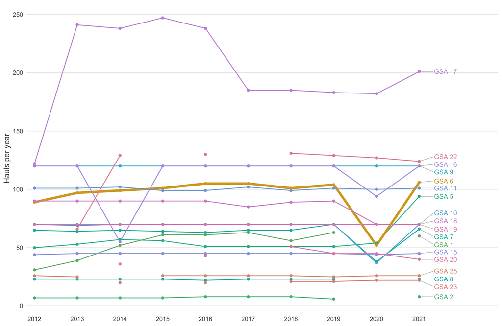

Figure 1: Number of MEDITS hauls per year in each GSA (colours as in the map; GSA 6 in bold gold). Breaks in a line, and isolated points, are years without a survey in that GSA.

```r
hpy <- hauls |>
  count(GSA, YEAR) |>
  complete(GSA, YEAR = 2012:2021) |>               # explicit NA so missing years break the line
  mutate(GSA = factor(GSA))
ends <- hpy |> filter(!is.na(n)) |> group_by(GSA) |> slice_max(YEAR, n = 1)
cols <- gsa_colours(hauls$GSA)
cols["6"] <- "#d9a520"                            # GSA 6 in gold, as on the map

ggplot(hpy, aes(YEAR, n, colour = GSA, group = GSA)) +
  geom_line(aes(linewidth = GSA == "6"), na.rm = TRUE) +
  geom_point(size = 1.4, na.rm = TRUE) +
  ggrepel::geom_text_repel(data = ends, aes(label = paste("GSA", GSA)),
                           nudge_x = 0.35, direction = "y", hjust = 0, size = 3.3,
                           segment.colour = "grey70", segment.size = 0.3,
                           min.segment.length = 0, box.padding = 0.12, seed = 1) +
  scale_colour_manual(values = cols, guide = "none") +
  scale_linewidth_manual(values = c(`FALSE` = 0.6, `TRUE` = 1.6), guide = "none") +
  scale_x_continuous(breaks = 2012:2021, expand = expansion(mult = c(0.02, 0.16))) +
  labs(x = NULL, y = "Hauls per year") +
  theme_ocean() + theme(panel.grid.major.x = element_blank())
```

Most GSAs are sampled at a near-constant number of hauls each year, but there are three notable exceptions: 2020 is missing in GSAs 1, 2 and 8 and roughly halved in GSAs 6, 7 and 10, most likely because of COVID-19 restrictions; the Greek GSAs (20, 22, 23) were not surveyed every year before 2018; and GSA 17 roughly doubled its sampling from 2013. In GSA 6, 2020 has 52 hauls against about 100 in other years, which matters for any year-by-year comparison.

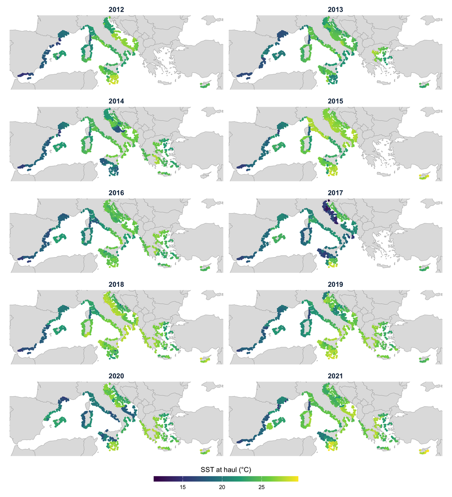

Figure 2: Sea surface temperature at the time of each haul.

```r
ggplot(hauls) + land +
  geom_point(aes(MEAN_LONGITUDE_DEC, MEAN_LATITUDE_DEC, colour = sst), size = 0.7) +
  scale_colour_viridis_c(name = "SST at haul (°C)") +
  med_view + facet_wrap(~YEAR, ncol = 2) + theme_map +
  guides(colour = guide_colourbar(barwidth = unit(16, "lines"), barheight = unit(0.6, "lines"),
                                  title.position = "top", title.hjust = 0.5)) +
  theme(strip.text = element_text(face = "bold", size = 11, colour = pal_ocean[["deep"]]),
        panel.spacing = unit(0.6, "lines"))
```

### 1.3 What AIS sees over time

Before using AIS effort as a covariate, it is worth checking how its coverage changes over the study period.

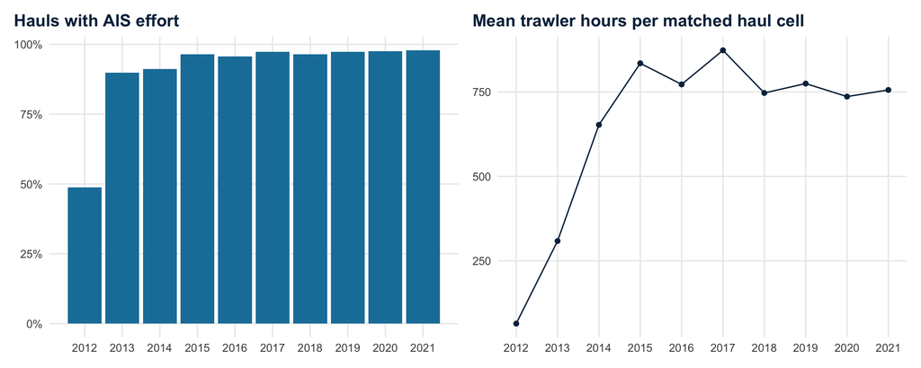

Figure 3: Share of MEDITS hauls with matched AIS trawler effort, and mean effort at matched hauls, by year. The 2012-2014 increase reflects AIS adoption by the fleet rather than more fishing.

```r
ais_cov <- hauls |>
  group_by(YEAR) |>
  summarise(matched = mean(!is.na(fishing_hours)),
            mean_hours = mean(fishing_hours, na.rm = TRUE), .groups = "drop")

(ggplot(ais_cov, aes(YEAR, matched)) +
   geom_col(fill = pal_ocean[["surface"]]) +
   scale_y_continuous(labels = percent) +
   labs(title = "Hauls with AIS effort", x = NULL, y = NULL)) +
(ggplot(ais_cov, aes(YEAR, mean_hours)) +
   geom_line(colour = pal_ocean[["deep"]]) +
   geom_point(colour = pal_ocean[["deep"]]) +
   labs(title = "Mean trawler hours per matched haul cell", x = NULL, y = NULL)) &
  scale_x_continuous(breaks = 2012:2021) & theme_ocean()
```

In 2012, only 49% of hauls fall in a cell with any AIS trawler effort, against 98% in 2021. Mean effort at matched hauls rises from 64 hours in 2012 to 835 in 2015, then stabilises.

> **Discussion point: AIS ramp-up.** Trawler AIS coverage at MEDITS hauls grows sharply over 2012-2014. Any comparison across these years (habitat change in Step 2, heatwave vs non-heatwave summers in Step 3) partly measures AIS uptake. Options: start in 2015, use effort per vessel, or treat early years separately.

## 2a. Species distribution model: total fish abundance

### 2a.1 Response variable

Species distribution models (SDMs) relate biological observations to environmental conditions to estimate habitat suitability and predict into unsampled locations. Here the response is **total fish abundance** per haul (N/km², all MEDITS faunistic categories A, Aa, Ae, Ao), modelled within a single GSA so that species-habitat relationships are reasonably homogeneous.

**Aggregate fish abundance per haul, keep GSA 6**

```r
spp.list <- read.csv("data/raw/MEDITS_listTM.csv", sep = ";")

fish <- med |>
  left_join(select(spp.list, MEDITS.Code, CATFAU),
            by = c("MEDITS_CODE" = "MEDITS.Code")) |>
  filter(CATFAU %in% c("A", "Aa", "Ae", "Ao")) |>
  group_by(id) |>
  summarise(across(-c(MEDITS_CODE, CATFAU, N_h, N_km2, kg_h, kg_km2), first),
            N_km2 = sum(N_km2, na.rm = TRUE), .groups = "drop") |>
  as.data.frame()

fish6 <- filter(fish, GSA == 6)
fish6$log_N_km2 <- log(fish6$N_km2)
```

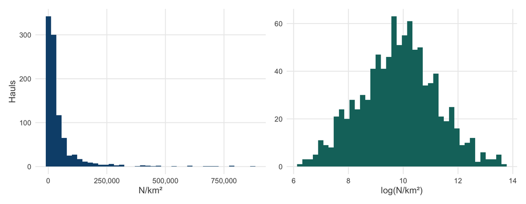

Figure 4: Distribution of total fish abundance in GSA 6 hauls, raw and log-transformed.

```r
(ggplot(fish6, aes(N_km2)) + geom_histogram(bins = 40, fill = pal_ocean[["mid"]]) +
   scale_x_continuous(labels = label_comma()) + labs(x = "N/km²", y = "Hauls")) +
(ggplot(fish6, aes(log_N_km2)) + geom_histogram(bins = 40, fill = pal_ocean[["accent"]]) +
   labs(x = "log(N/km²)", y = NULL)) & theme_ocean()
```

GSA 6 contributes 959 hauls. Abundance is strongly right-skewed, so it is modelled on the log scale.

### 2a.2 Collinearity

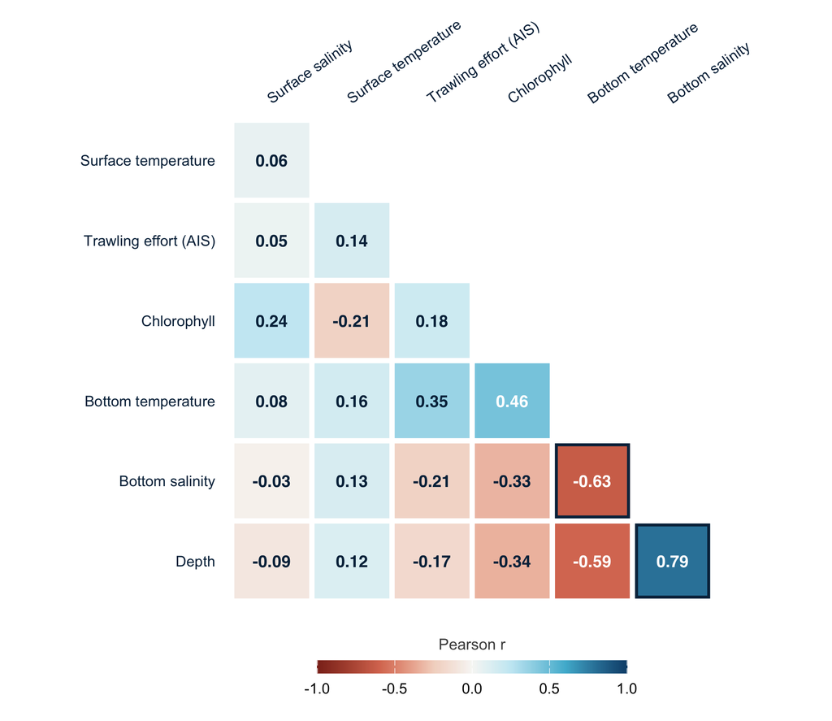

Figure 5: Pairwise Pearson correlations among candidate predictors in GSA 6 hauls. Variables are ordered by hierarchical clustering so that correlated groups sit together; pairs with |r| above 0.6 are outlined.

```r
# Readable names for predictors
var_labels <- c(sst = "Surface temperature", botTemp = "Bottom temperature",
                so = "Surface salinity", botso = "Bottom salinity",
                chl = "Chlorophyll", MEAN_DEPTH = "Depth", depth = "Depth",
                fishing_hours = "Trawling effort (AIS)")

# Lower-triangle correlation heatmap, clustered, with |r| > threshold outlined
cor_heatmap <- function(df, threshold = 0.6) {
  m <- cor(df, use = "pairwise.complete.obs")
  ord <- hclust(as.dist(1 - abs(m)))$order
  m <- m[ord, ord]
  labs <- unname(var_labels[colnames(m)])
  dimnames(m) <- list(labs, labs)

  d <- as.data.frame(as.table(m)) |>
    setNames(c("x", "y", "r")) |>
    mutate(i = as.integer(x), j = as.integer(y)) |>
    filter(i < j) |>
    mutate(x = factor(x, labs), y = factor(y, rev(labs)),
           strong = abs(r) > threshold,
           txt = ifelse(abs(r) > 0.45, "white", pal_ocean[["deep"]]))

  ggplot(d, aes(x, y)) +
    geom_tile(aes(fill = r), colour = "white", linewidth = 1.6) +
    geom_tile(data = filter(d, strong), fill = NA, colour = pal_ocean[["deep"]],
              linewidth = 0.9, width = 0.9, height = 0.9) +
    geom_text(aes(label = sprintf("%.2f", r), colour = txt), size = 3.8,
              fontface = "bold", family = "sans") +
    scale_colour_identity() +
    scale_fill_gradientn(
      colours = c("#8c2d1f", "#d9785f", "#f3d6c8", "#f7f7f5", "#c8eaf4", "#4eb8d4", "#0d4f7a"),
      values = scales::rescale(c(-1, -0.6, -0.25, 0, 0.25, 0.6, 1)),
      limits = c(-1, 1), breaks = c(-1, -0.5, 0, 0.5, 1),
      name = "Pearson r") +
    scale_x_discrete(position = "top", drop = TRUE) +
    scale_y_discrete(drop = TRUE) +
    coord_fixed() +
    guides(fill = guide_colourbar(barwidth = unit(14, "lines"), barheight = unit(0.6, "lines"),
                                  title.position = "top", title.hjust = 0.5,
                                  ticks.colour = "white", frame.colour = NA)) +
    theme_minimal(base_size = 12) +
    theme(axis.title = element_blank(),
          axis.text.x.top = element_text(angle = 35, hjust = 0, vjust = 0,
                                         colour = pal_ocean[["deep"]]),
          axis.text.y = element_text(colour = pal_ocean[["deep"]]),
          panel.grid = element_blank(),
          legend.position = "bottom",
          legend.title = element_text(colour = "grey30", size = 10),
          plot.margin = margin(10, 30, 10, 10))
}

vars <- select(fish6, sst, botTemp, so, botso, chl, MEAN_DEPTH, fishing_hours)
cor.mat <- cor(vars, use = "pairwise.complete.obs")
cor_heatmap(vars)
```

The group’s script uses `usdm::vif()` and `vifstep(th = 3)`. The same variance inflation factors are computed below from auxiliary regressions.

**Variance inflation factors**

```r
vif_manual <- function(df) {
  df <- na.omit(df)
  sapply(names(df), function(v) {
    r2 <- summary(lm(reformulate(setdiff(names(df), v), v), data = df))$r.squared
    1 / (1 - r2)
  })
}
vif_tab <- tibble(variable = names(vars), VIF = round(vif_manual(vars), 2))
kable(vif_tab)
```

Table 2: Variance inflation factors (VIF) of the candidate predictors of the total fish model, GSA 6 hauls. variable: predictor (sst: sea surface temperature, °C; botTemp: bottom temperature, °C; so: surface salinity, PSU; botso: bottom salinity, PSU; chl: surface chlorophyll-a, mg/m³; MEAN_DEPTH: mean haul depth, m; fishing_hours: GFW AIS apparent trawler fishing hours in the haul’s 0.1° cell and year). VIF: 1 / (1 − R²) of the regression of that predictor on all the others; values above 3 indicate problematic collinearity.

| variable | VIF |
| --- | --- |
| sst | 1.30 |
| botTemp | 2.43 |
| so | 1.10 |
| botso | 3.14 |
| chl | 1.53 |
| MEAN_DEPTH | 2.85 |
| fishing_hours | 1.16 |

Collinearity is moderate overall. Bottom salinity (`botso`) is the only variable above the VIF threshold of 3, driven by its correlation with depth (r = 0.79) and bottom temperature (r = -0.63), and is dropped. Depth (VIF just under 3) is left out of the candidate set, its information being largely carried by bottom temperature.

### 2a.3 GAM fitting and selection

Generalised additive models (GAMs, `mgcv`) allow smooth, non-linear responses. Smooths are capped at `k = 4` to keep response curves ecologically interpretable, and `select = TRUE` adds a shrinkage penalty so that unhelpful terms can be shrunk to zero. Hauls with any missing predictor are removed.

**Fit the full and reduced GAMs**

```r
fish6 <- na.omit(fish6)

gam1 <- gam(log_N_km2 ~ s(sst, k = 4) + s(botTemp, k = 4) + s(so, k = 4) +
              s(chl, k = 4) + s(fishing_hours, k = 4),
            family = gaussian, data = fish6, method = "REML", select = TRUE)

gam2 <- gam(log_N_km2 ~ s(botTemp, k = 4) + s(so, k = 4) + s(chl, k = 4) +
              s(fishing_hours, k = 4),
            family = gaussian, data = fish6, method = "REML", select = TRUE)

gam_tab <- tibble(
  model = c("gam1: full", "gam2: without SST"),
  n = c(nobs(gam1), nobs(gam2)),
  `R² (adj.)` = round(c(summary(gam1)$r.sq, summary(gam2)$r.sq), 3),
  `Deviance explained` = percent(c(summary(gam1)$dev.expl, summary(gam2)$dev.expl), 0.1),
  AIC = round(c(AIC(gam1), AIC(gam2)), 1))
```

Table 3: Comparison of the two total fish GAMs (Gaussian, response log(N/km²)). model: predictor set (gam1: bottom temperature, SST, surface salinity, chlorophyll and fishing hours; gam2: the same without SST). n: number of hauls used. R² (adj.): adjusted R². Deviance explained: share of the null deviance explained by the model. AIC: Akaike information criterion (lower is better).

| model | n | R² (adj.) | Deviance explained | AIC |
| --- | --- | --- | --- | --- |
| gam1: full | 916 | 0.203 | 20.9% | 3000.8 |
| gam2: without SST | 916 | 0.203 | 20.9% | 3000.8 |

**Smooth terms of the retained model (gam2)**

```r
s_tab <- as.data.frame(summary(gam2)$s.table)
kable(tibble(term = rownames(s_tab), edf = round(s_tab$edf, 2),
             F = round(s_tab$F, 2),
             `p-value` = format.pval(s_tab$`p-value`, digits = 2, eps = 1e-4)))
```

Table 4: Smooth terms of the retained total fish model (gam2). term: smooth function s() of each predictor. edf: effective degrees of freedom (1 = linear; close to 0 = shrunk out of the model by select = TRUE). F: test statistic for the term. p-value: approximate significance of the term.

| term | edf | F | p-value |
| --- | --- | --- | --- |
| s(botTemp) | 2.94 | 57.61 | <1e-04 |
| s(so) | 1.48 | 2.43 | 0.0075 |
| s(chl) | 0.85 | 1.84 | 0.0100 |
| s(fishing_hours) | 1.27 | 1.24 | 0.0562 |

**All-subsets selection on gam1 with MuMIn::dredge**

```r
options(na.action = "na.fail")
all.models <- dredge(gam1, rank = "AICc")
options(na.action = "na.omit")

top <- as.data.frame(head(all.models, 6))
kable(top |>
        mutate(across(where(is.numeric), \(x) round(x, 2))) |>
        mutate(across(starts_with("s("), \(x) ifelse(is.na(x), "", "+"))) |>
        select(-any_of("(Intercept)")))
```

Table 5: Six best models of the all-subsets selection on gam1 (MuMIn::dredge), ranked by AICc. s() columns: ‘+’ if the smooth of that predictor is in the model, blank if not. df: number of estimated parameters. logLik: log-likelihood. AICc: AIC corrected for small samples. delta: AICc difference from the best model. weight: Akaike weight, the relative support for each model among all those fitted.

|  | s(botTemp, k = 4) | s(chl, k = 4) | s(fishing_hours, k = 4) | s(so, k = 4) | s(sst, k = 4) | df | logLik | AICc | delta | weight |
| --- | --- | --- | --- | --- | --- | --- | --- | --- | --- | --- |
| 16 | + | + | + | + |  | 9 | -1490.88 | 3000.98 | 0.00 | 0.32 |
| 32 | + | + | + | + | + | 9 | -1490.88 | 3000.99 | 0.00 | 0.32 |
| 12 | + | + |  | + |  | 7 | -1493.40 | 3002.61 | 1.62 | 0.14 |
| 28 | + | + |  | + | + | 7 | -1493.40 | 3002.61 | 1.62 | 0.14 |
| 14 | + |  | + | + |  | 8 | -1494.05 | 3005.35 | 4.36 | 0.04 |
| 30 | + |  | + | + | + | 9 | -1492.70 | 3005.48 | 4.49 | 0.03 |

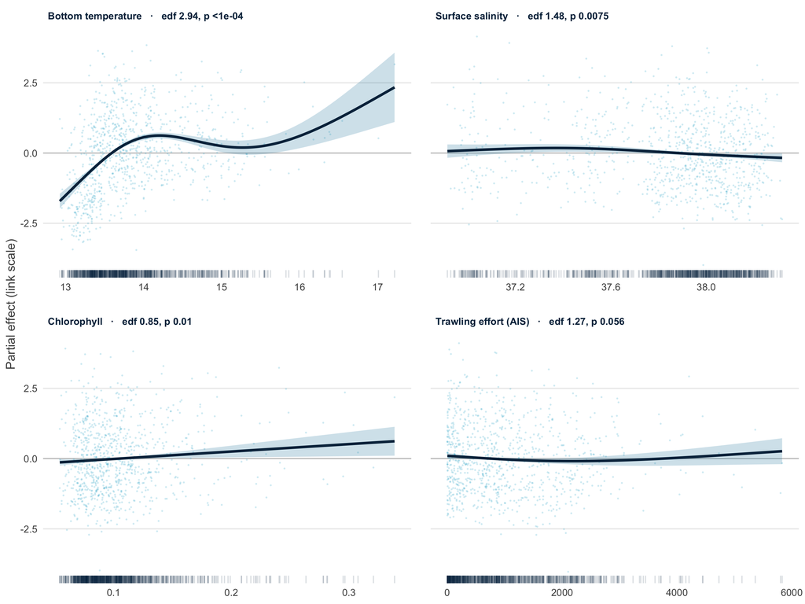

Figure 6: Partial effects of the retained model (gam2) on log abundance: estimated smooth (line), 95% confidence band (shaded), partial residuals (points) and data coverage (rug). Each panel title gives the effective degrees of freedom and p-value.

```r
# ggplot partial-effect plots for an mgcv GAM (no extra packages needed)
gam_smooths <- function(model, residuals = TRUE, ncol = 2, n = 200) {
  dat  <- model$model
  resp <- all.vars(formula(model))[1]
  st   <- summary(model)$s.table
  med  <- lapply(dat[setdiff(names(dat), resp)],
                 \(x) if (is.numeric(x)) median(x, na.rm = TRUE) else x[1])
  term_obs <- predict(model, type = "terms")
  res_w    <- residuals(model, type = "working")

  pieces <- lapply(model$smooth, function(sm) {
    v   <- sm$term
    lab <- sm$label
    head <- sprintf("%s   ·   edf %.2f, p %s", unname(var_labels[v]) %||% v, st[lab, "edf"],
                    format.pval(st[lab, 4], digits = 2, eps = 1e-4))
    nd <- as.data.frame(med)[rep(1, n), , drop = FALSE]
    nd[[v]] <- seq(min(dat[[v]]), max(dat[[v]]), length.out = n)
    p <- predict(model, nd, type = "terms", se.fit = TRUE)
    list(
      curve = tibble(term = head, x = nd[[v]], fit = p$fit[, lab],
                     lo = p$fit[, lab] - 1.96 * p$se.fit[, lab],
                     hi = p$fit[, lab] + 1.96 * p$se.fit[, lab]),
      pts = tibble(term = head, x = dat[[v]], pr = term_obs[, lab] + res_w))
  })
  curves <- bind_rows(lapply(pieces, `[[`, "curve"))
  pts    <- bind_rows(lapply(pieces, `[[`, "pts"))
  lvls   <- unique(curves$term)
  curves$term <- factor(curves$term, lvls); pts$term <- factor(pts$term, lvls)

  g <- ggplot(curves, aes(x)) +
    geom_hline(yintercept = 0, colour = "grey75", linewidth = 0.4)
  if (residuals)
    g <- g + geom_point(data = pts, aes(x, pr), colour = pal_ocean[["light"]],
                        alpha = 0.25, size = 0.8, stroke = 0)
  g + geom_ribbon(aes(ymin = lo, ymax = hi), fill = pal_ocean[["surface"]], alpha = 0.22) +
    geom_line(aes(y = fit), colour = pal_ocean[["deep"]], linewidth = 1.1) +
    geom_rug(data = pts, aes(x), sides = "b", alpha = 0.15, length = unit(0.03, "npc"),
             colour = pal_ocean[["deep"]]) +
    facet_wrap(~ term, scales = "free_x", ncol = ncol) +
    labs(x = NULL, y = "Partial effect (link scale)") +
    theme_ocean() +
    theme(strip.text = element_text(face = "bold", hjust = 0, colour = pal_ocean[["deep"]]),
          panel.grid.major.x = element_blank(),
          panel.spacing = unit(1.2, "lines"))
}

# Four-panel residual diagnostics in ggplot.
# Gaussian models use deviance residuals. Tweedie models (many exact zeros) use
# simulated randomised quantile residuals (Dunn & Smyth 1996, as in DHARMa),
# which are standard normal if the model is correct.
gam_diagnostics <- function(model, nsim = 500, seed = 1) {
  fam <- model$family$family
  mu  <- fitted(model); y <- model$y
  if (grepl("Tweedie", fam)) {
    set.seed(seed)
    p   <- model$family$getTheta(TRUE); phi <- model$sig2
    sim <- vapply(seq_len(nsim), \(i) rTweedie(mu, p = p, phi = phi), numeric(length(mu)))
    lo  <- rowSums(sim < y); eq <- rowSums(sim == y)
    q   <- (lo + runif(length(y)) * (eq + 1)) / (nsim + 1)
    res <- qnorm(q); res_lab <- "Quantile residuals"
    xs  <- rank(mu) / length(mu); x_lab <- "Fitted (rank-transformed)"
    log_axes <- TRUE
  } else {
    res <- residuals(model, type = "deviance") / sqrt(model$sig2)
    res_lab <- "Standardised residuals"
    xs  <- model$linear.predictors; x_lab <- "Linear predictor"
    log_axes <- FALSE
  }
  d  <- tibble(x = xs, fitted = mu, obs = y, res = res)
  pt <- function(...) geom_point(colour = pal_ocean[["surface"]], alpha = 0.45, size = 1.1, stroke = 0, ...)

  p1 <- ggplot(d, aes(sample = res)) +
    geom_abline(colour = pal_ocean[["alert"]], linewidth = 0.8) +
    geom_qq(colour = pal_ocean[["surface"]], alpha = 0.45, size = 1.1, stroke = 0) +
    labs(title = "Q-Q plot", x = "Theoretical quantiles", y = res_lab)
  p2 <- ggplot(d, aes(x, res)) + geom_hline(yintercept = 0, linetype = 2, colour = "grey50") +
    pt() + geom_smooth(method = "loess", formula = y ~ x, se = FALSE,
                       colour = pal_ocean[["alert"]], linewidth = 0.9) +
    labs(title = "Residuals vs fitted", x = x_lab, y = res_lab)
  p3 <- ggplot(d, aes(res)) +
    geom_histogram(bins = 40, fill = pal_ocean[["mid"]], colour = "white", linewidth = 0.2) +
    labs(title = "Residual distribution", x = res_lab, y = "Hauls")
  p4 <- ggplot(d, aes(fitted, obs)) + geom_abline(linetype = 2, colour = "grey50") + pt() +
    labs(title = "Observed vs fitted", x = "Fitted", y = "Observed")
  if (log_axes) {
    plog <- scales::pseudo_log_trans(sigma = 10, base = 10)
    br <- c(0, 10, 100, 1000, 10000)
    p4 <- p4 + scale_x_continuous(trans = plog, breaks = br, labels = label_comma()) +
      scale_y_continuous(trans = plog, breaks = br, labels = label_comma()) +
      labs(x = "Fitted N/km²", y = "Observed N/km²")
  }
  (p1 + p2) / (p3 + p4) & theme_ocean()
}

gam_smooths(gam2)
```

The two GAMs are identical in fit: with `select = TRUE`, the SST smooth in `gam1` is already shrunk to zero, so removing it changes nothing. The group retained `gam2` (bottom temperature, salinity, chlorophyll, fishing hours). Bottom temperature carries most of the signal. Fishing hours is in the lowest-AICc model, but its smooth is only marginally significant (p ≈ 0.06) and models without it are within 2 AICc units. The model explains about a fifth of the deviance in log abundance, which is typical for haul-level survey data but a reminder that much of the variation is unexplained.

**Residual checks**

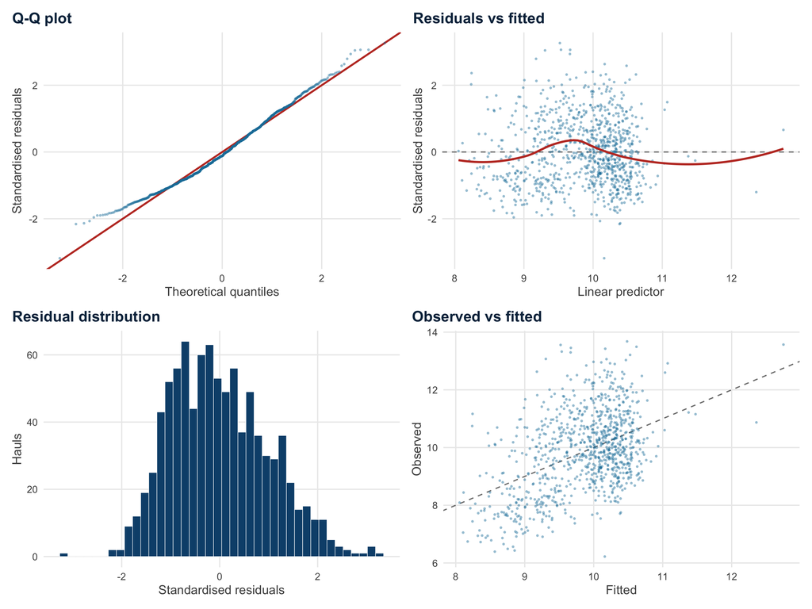

Residual diagnostics for gam2. Points close to the red line in the Q-Q plot, a flat smoother in the residuals panel and a symmetric histogram indicate that the Gaussian model on log abundance is adequate.

```r
gam_diagnostics(gam2)
```

**Basis dimension check (k-index)**

```r
kc <- as.data.frame(k.check(gam2))
kable(tibble(term = rownames(kc), `k'` = kc[[1]], edf = round(kc$edf, 2),
             `k-index` = round(kc$`k-index`, 2), `p-value` = signif(kc$`p-value`, 2)))
```

Table 6: Basis dimension check of the gam2 smooths (mgcv::k.check). term: smooth term. k’: maximum effective degrees of freedom allowed by the basis (k − 1). edf: effective degrees of freedom used. k-index: ratio of the residual variance between neighbouring observations to the overall residual variance; values well below 1 suggest the basis is too small. p-value: from a randomisation test of the k-index; small values flag a possibly too small basis.

| term | k’ | edf | k-index | p-value |
| --- | --- | --- | --- | --- |
| s(botTemp) | 3 | 2.94 | 0.99 | 0.39 |
| s(so) | 3 | 1.48 | 0.98 | 0.20 |
| s(chl) | 3 | 0.85 | 1.00 | 0.52 |
| s(fishing_hours) | 3 | 1.27 | 0.98 | 0.28 |

A k-index well below 1 with a small p-value would suggest the basis is too small (`k = 4`) for that term. The smooths here are deliberately constrained to stay ecologically interpretable, so a low k-index is a prompt to look at the residual pattern rather than to raise `k` automatically.

> **Discussion point: zeros in effort.** Hauls without matched AIS effort have `fishing_hours = NA` and are removed by `na.omit()`, so the model is fitted only on fished cells. On the prediction grid, missing effort is set to 0, outside the fitted range. Treating unmatched hauls as zero effort in both places, or adding a fished / not fished indicator, would make the two consistent.

### 2a.4 Prediction and habitat change

The fitted model is projected over the Copernicus hindcast grid for July of each year.

**Predict on the hindcast grid (not evaluated: 266 MB input)**

```r
new.env <- read.csv("data/raw/MED.env_grid_hindcast_2012_2021.csv") |>
  drop_na(GSA, sst, botTemp, so, botso, chl) |>
  mutate(fishing_hours = replace_na(fishing_hours, 0))
new.env6 <- filter(new.env, GSA == 6, MONTH == 7)

gam.pred <- predict.gam(gam2, new.env6, se.fit = TRUE, type = "response")
fish.pred6 <- new.env6 |>
  mutate(fit = gam.pred$fit, se.fit = gam.pred$se.fit,
         lwr = fit - 1.96 * se.fit, upr = fit + 1.96 * se.fit)
write.table(fish.pred6, "outputs/Final_gam_prediction.csv", sep = ";", row.names = FALSE)
```

Because the model is fitted to log abundance, `fit` is on the log scale. Predictions are back-transformed to abundance (N/km² = exp(fit)) before mapping and before computing change between years. The usual lognormal bias correction, exp(σ²/2), multiplies every prediction by the same constant, so it cancels in percentage change and is omitted here.

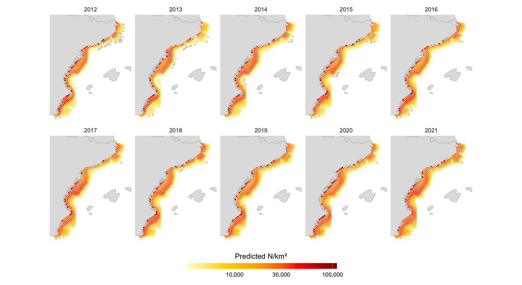

Figure 7: Predicted July fish abundance (N/km², log colour scale) in GSA 6, 2012-2021. Grey cells have a bottom temperature outside the range of the GSA 6 hauls used to fit the model (extrapolation).

```r
fish.pred6 <- read.csv("outputs/Final_gam_prediction.csv", sep = ";")

# Flag grid cells whose bottom temperature lies outside the range of the fitting data.
# Bottom temperature is the only strong, non-linear term, and the only one whose
# extrapolation produces implausible abundances; the other smooths are nearly flat.
bt_range <- range(fish6$botTemp)
fish.pred6 <- fish.pred6 |>
  mutate(N = exp(fit),
         extrapolated = botTemp < bt_range[1] | botTemp > bt_range[2])

N_lims <- quantile(fish.pred6$N[!fish.pred6$extrapolated], c(0.01, 0.99))

ggplot(fish.pred6) + land +
  geom_point(data = filter(fish.pred6, extrapolated), aes(grid.X, grid.Y),
             colour = "grey75", size = 0.45) +
  geom_point(data = filter(fish.pred6, !extrapolated), aes(grid.X, grid.Y, colour = N),
             size = 0.45) +
  scale_colour_gradientn(colours = c("lightyellow", "gold", "orange", "red", "darkred"),
                         trans = "log10", limits = N_lims, oob = squish,
                         labels = label_comma(), name = "Predicted N/km²") +
  guides(colour = guide_colourbar(barwidth = unit(16, "lines"), barheight = unit(0.6, "lines"),
                                  title.position = "top", title.hjust = 0.5)) +
  gsa6_view + facet_wrap(~year, ncol = 5) + theme_map
```

**Change in predicted abundance 2012-2021, on the abundance scale**

```r
fish.change6 <- fish.pred6 |>
  filter(year %in% c(2012, 2021)) |>
  select(grid.id, grid.X, grid.Y, year, N, extrapolated) |>
  pivot_wider(names_from = year, values_from = c(N, extrapolated)) |>
  mutate(difference   = N_2021 - N_2012,
         perc.change  = 100 * (N_2021 / N_2012 - 1),
         extrapolated = extrapolated_2012 | extrapolated_2021) |>
  select(-extrapolated_2012, -extrapolated_2021)

# The group's outputs/fish.change6.csv is left untouched; the corrected table is saved alongside it
write.csv(fish.change6, "outputs/fish.change6_abundance.csv", row.names = FALSE)
```

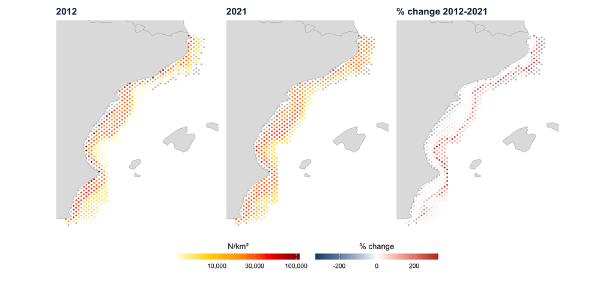

Figure 8: Predicted total fish abundance in 2012 and 2021 (N/km², log colour scale) and percentage change 2012-2021. Grey cells are extrapolated in at least one of the two years.

```r
ok <- filter(fish.change6, !extrapolated)
ex <- filter(fish.change6, extrapolated)
chg_lim <- quantile(abs(ok$perc.change), 0.98, na.rm = TRUE)

change_map <- function(var, title, scale) {
  ggplot() + land +
    geom_point(data = ex, aes(grid.X, grid.Y), colour = "grey75", size = 0.5) +
    geom_point(data = ok, aes(grid.X, grid.Y, colour = .data[[var]]), size = 0.5) +
    scale + labs(title = title) + gsa6_view + theme_map
}
bar  <- guide_colourbar(barwidth = unit(12, "lines"), barheight = unit(0.6, "lines"),
                        title.position = "top", title.hjust = 0.5)
dens <- scale_colour_gradientn(colours = c("lightyellow", "gold", "orange", "red", "darkred"),
                               trans = "log10", limits = N_lims, oob = squish,
                               breaks = c(3000, 10000, 30000, 1e5), labels = label_comma(),
                               name = "N/km²", guide = bar)

(change_map("N_2012", "2012", dens) + change_map("N_2021", "2021", dens) +
 change_map("perc.change", "% change 2012-2021",
            scale_colour_gradient2(low = pal_ocean[["mid"]], mid = "white", high = pal_ocean[["alert"]],
                                   midpoint = 0, limits = c(-chg_lim, chg_lim), oob = squish,
                                   name = "% change", guide = bar))) +
  plot_layout(guides = "collect") & theme(legend.position = "bottom")
```

Across the 442 grid cells within the sampled bottom-temperature range in both years (of 522), the median change in predicted total fish abundance from 2012 to 2021 is 45%, and 23% of cells decline. Changes this large over a decade are unlikely to be purely environmental: the 2012 predictions use near-zero AIS effort (Step 1), so part of the contrast comes from the fishing-hours smooth.

> **Discussion point: extrapolation in July.** The model is fitted on MEDITS hauls from May and June, all deeper than 35 m, but predicts for July over the whole grid. In shallow coastal cells, July bottom temperature reaches 26.9 °C, against a maximum of 17.2 °C in the fitting data, and the rising bottom-temperature smooth then produces implausibly high abundances (up to 9 × 10<sup>11</sup> individuals per km²). 11% of grid-year predictions fall outside the sampled bottom-temperature range; they are shown in grey and excluded from the change summary above. Predicting for June, as in Section 2b, and restricting the grid to the sampled depth range would avoid most of this.

## 2b. Species distribution model: red mullet

The group has since chosen to focus on **red mullet** (*Mullus barbatus*, MEDITS code `MULLBAR`), a key commercial target of the GSA 6 bottom-trawl fleet. This section repeats the SDM workflow of Section 2a for that species, with three changes that follow from the discussion points above:

- **Absences are added back.** MEDITS only lists species that were caught, so hauls without red mullet are filled in as zero abundance.
- **A Tweedie GAM replaces the Gaussian model on log abundance.** The Tweedie distribution handles exact zeros and skewed positive values in one model, and predictions come out directly as N/km², so no back-transformation is needed.
- **Depth is added as a candidate predictor**, since red mullet is mainly a continental-shelf species, and hauls without matched AIS effort are set to zero effort in both fitting and prediction.

### 2b.1 Response variable

**Build the red mullet haul table for GSA 6, with zeros**

```r
hauls6 <- med |>
  filter(GSA == 6) |>
  distinct(id, .keep_all = TRUE) |>
  select(id, YEAR, MONTH, lon = MEAN_LONGITUDE_DEC, lat = MEAN_LATITUDE_DEC,
         depth = MEAN_DEPTH, sst, botTemp, so, chl, fishing_hours)

mull6 <- hauls6 |>
  left_join(med |> filter(MEDITS_CODE == "MULLBAR") |> select(id, N_km2, kg_km2),
            by = "id") |>
  mutate(N_km2 = replace_na(N_km2, 0),
         kg_km2 = replace_na(kg_km2, 0),
         present = N_km2 > 0,
         fishing_hours = replace_na(fishing_hours, 0)) |>
  drop_na(botTemp, so, chl, depth)
```

Red mullet was caught in 634 of 959 GSA 6 hauls (66%), with a median density of 518 individuals per km² where present.

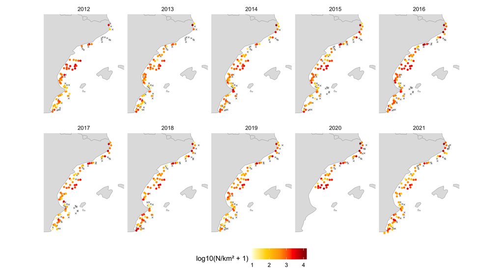

Figure 9: Red mullet in GSA 6 MEDITS hauls, 2012-2021. Grey crosses are hauls where the species was not caught.

```r
ggplot() + land +
  geom_point(data = filter(mull6, !present), aes(lon, lat),
             shape = 4, size = 0.6, colour = "grey55") +
  geom_point(data = filter(mull6, present), aes(lon, lat, colour = log10(N_km2 + 1)),
             size = 0.9) +
  scale_colour_gradientn(colours = c("lightyellow", "gold", "orange", "red", "darkred"),
                         name = "log10(N/km² + 1)") +
  gsa6_view + facet_wrap(~YEAR, ncol = 5) + theme_map
```

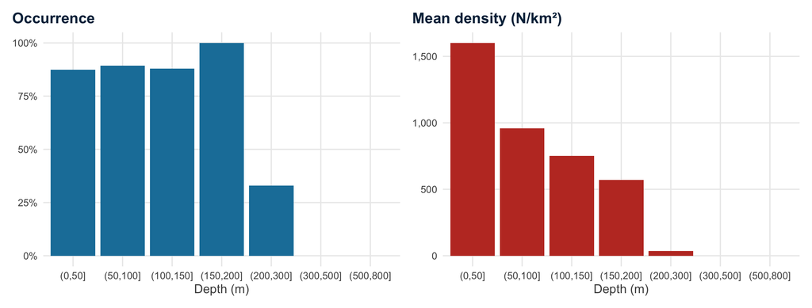

Figure 10: Red mullet occurrence and mean density by haul depth.

```r
mb_depth_tab <- mull6 |>
  mutate(depth_bin = cut(depth, c(0, 50, 100, 150, 200, 300, 500, 800), dig.lab = 4)) |>
  group_by(depth_bin) |>
  summarise(hauls = n(), occurrence = mean(present), mean_N = mean(N_km2), .groups = "drop")

(ggplot(mb_depth_tab, aes(depth_bin, occurrence)) +
   geom_col(fill = pal_ocean[["surface"]]) +
   scale_y_continuous(labels = percent) +
   labs(title = "Occurrence", x = "Depth (m)", y = NULL)) +
(ggplot(mb_depth_tab, aes(depth_bin, mean_N)) +
   geom_col(fill = pal_ocean[["alert"]]) +
   scale_y_continuous(labels = label_comma()) +
   labs(title = "Mean density (N/km²)", x = "Depth (m)", y = NULL)) & theme_ocean()
```

### 2b.2 Collinearity

**Variance inflation factors for the red mullet predictors**

```r
mb_vars <- select(mull6, botTemp, so, chl, depth, fishing_hours)
kable(tibble(variable = names(mb_vars), VIF = round(vif_manual(mb_vars), 2)))
```

Table 7: Variance inflation factors of the red mullet predictors, all GSA 6 hauls (zeros included). variable: botTemp: bottom temperature, °C; so: surface salinity, PSU; chl: surface chlorophyll-a, mg/m³; depth: haul depth, m; fishing_hours: GFW AIS apparent trawler fishing hours in the haul’s 0.1° cell and year (0 when unmatched). VIF: 1 / (1 − R²) of the regression of that predictor on all the others; values above 3 indicate problematic collinearity.

| variable | VIF |
| --- | --- |
| botTemp | 1.93 |
| so | 1.06 |
| chl | 1.34 |
| depth | 1.57 |
| fishing_hours | 1.16 |

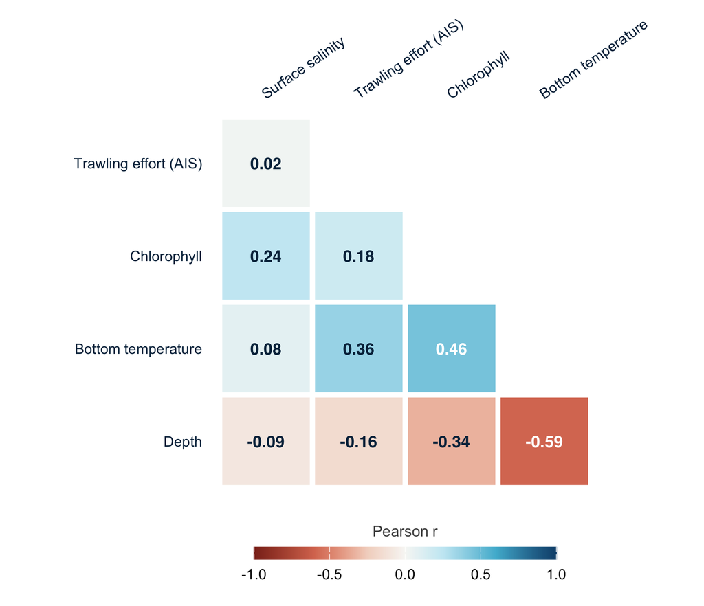

Figure 11: Pairwise correlations among the red mullet model predictors (all GSA 6 hauls, zeros included).

```r
cor_heatmap(mb_vars)
```

### 2b.3 GAM fitting

Two models are compared: one with the predictors retained by the group in Section 2a, and one adding depth. Settings are otherwise the same (`k = 4`, REML, `select = TRUE`), with a Tweedie family and log link.

**Fit Tweedie GAMs for red mullet density**

```r
mb_env <- gam(N_km2 ~ s(botTemp, k = 4) + s(so, k = 4) + s(chl, k = 4) +
                s(fishing_hours, k = 4),
              family = tw(link = "log"), data = mull6, method = "REML", select = TRUE)

mb_depth <- gam(N_km2 ~ s(botTemp, k = 4) + s(so, k = 4) + s(chl, k = 4) +
                  s(depth, k = 4) + s(fishing_hours, k = 4),
                family = tw(link = "log"), data = mull6, method = "REML", select = TRUE)

mb_tab <- tibble(
  model = c("Section 2a predictors", "Section 2a predictors + depth"),
  n = c(nobs(mb_env), nobs(mb_depth)),
  `Deviance explained` = percent(c(summary(mb_env)$dev.expl, summary(mb_depth)$dev.expl), 0.1),
  AIC = round(c(AIC(mb_env), AIC(mb_depth)), 1),
  `Tweedie p` = round(c(mb_env$family$getTheta(TRUE), mb_depth$family$getTheta(TRUE)), 2))
```

Table 8: Comparison of the two red mullet GAMs (Tweedie, log link, response N/km², zeros included). model: predictor set (bottom temperature, surface salinity, chlorophyll and fishing hours, with or without depth). n: number of hauls used. Deviance explained: share of the null deviance explained by the model. AIC: Akaike information criterion (lower is better). Tweedie p: estimated Tweedie power parameter, between 1 (Poisson-like) and 2 (gamma-like), which sets how the variance grows with the mean.

| model | n | Deviance explained | AIC | Tweedie p |
| --- | --- | --- | --- | --- |
| Section 2a predictors | 959 | 20.0% | 11022.3 | 1.60 |
| Section 2a predictors + depth | 959 | 51.2% | 10511.3 | 1.63 |

**Smooth terms of the depth model**

```r
s_mb <- as.data.frame(summary(mb_depth)$s.table)
kable(tibble(term = rownames(s_mb), edf = round(s_mb$edf, 2),
             F = round(s_mb[[3]], 2),
             `p-value` = format.pval(s_mb[[4]], digits = 2, eps = 1e-4)))
```

Table 9: Smooth terms of the red mullet depth model. term: smooth function s() of each predictor. edf: effective degrees of freedom (1 = linear; close to 0 = shrunk out of the model). F: test statistic for the term. p-value: approximate significance of the term.

| term | edf | F | p-value |
| --- | --- | --- | --- |
| s(botTemp) | 1.61 | 3.25 | 0.002 |
| s(so) | 1.19 | 1.06 | 0.068 |
| s(chl) | 1.85 | 9.38 | <1e-04 |
| s(depth) | 2.24 | 102.83 | <1e-04 |
| s(fishing_hours) | 2.78 | 8.84 | <1e-04 |

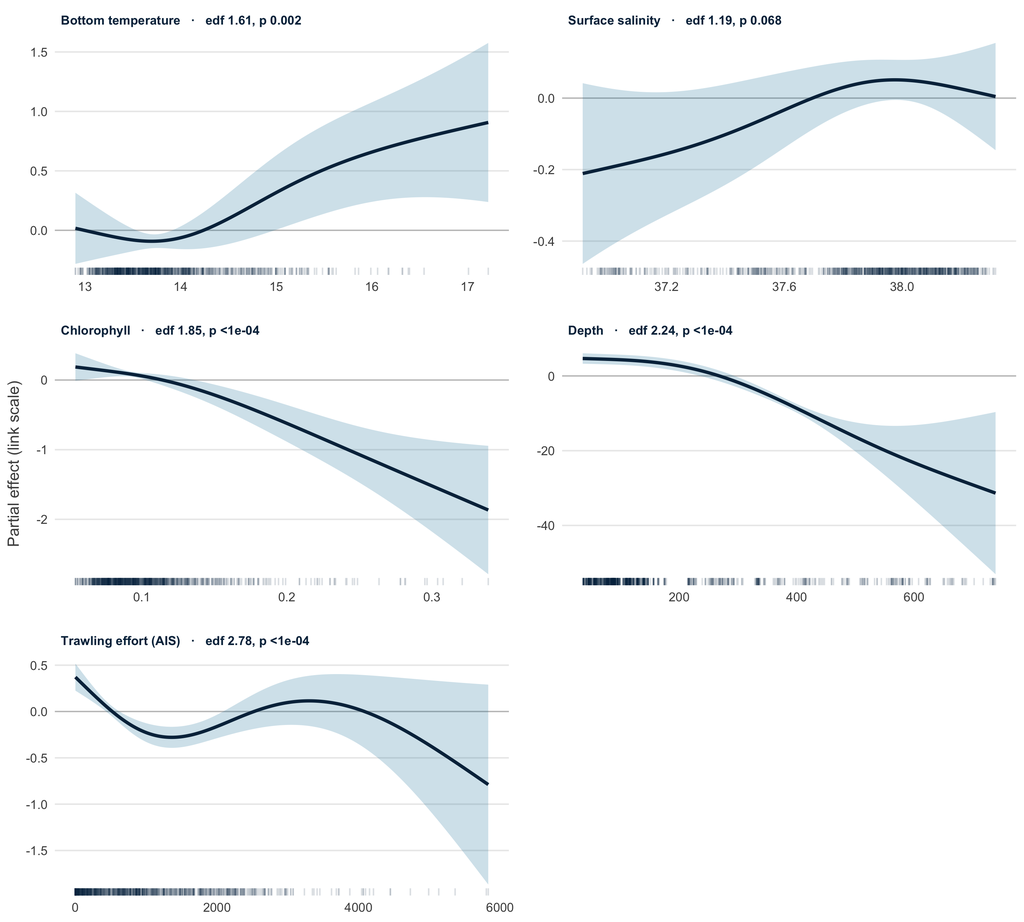

Figure 12: Partial effects of the red mullet depth model on the log-link scale, with 95% confidence bands and data coverage (rug). Panels have free y axes because the depth effect is an order of magnitude larger than the others.

```r
gam_smooths(mb_depth, residuals = FALSE) +
  facet_wrap(~ term, scales = "free", ncol = 2)
```

**Residual checks for the red mullet model**

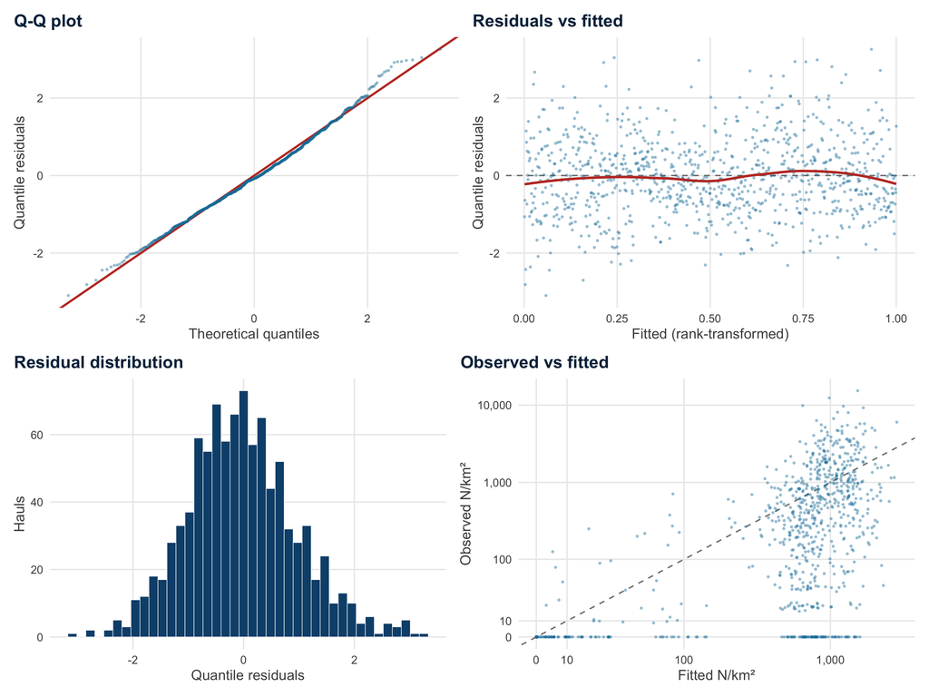

Figure 13: Residual diagnostics for the red mullet Tweedie GAM, using simulated quantile residuals (500 simulations), which should follow the red 1:1 line in the Q-Q plot and show no trend against fitted values if the model is adequate. Observed vs fitted uses pseudo-log axes so that hauls with zero catch are shown along the bottom.

```r
gam_diagnostics(mb_depth)
```

The quantile residuals follow the 1:1 line closely and show no trend against fitted values, so the Tweedie distribution handles the mix of zeros and large catches well overall. The observed-vs-fitted panel shows the main weakness: many hauls with no red mullet are predicted at several hundred individuals per km². The model captures *where* red mullet habitat is, but not the haul-to-haul patchiness within it.

Depth transforms the model: deviance explained rises from 20% to 51%, and AIC drops by 511 units. Predicted density is high and fairly flat down to about 200 m, then falls steeply on the slope, consistent with red mullet’s known shelf distribution. Among the environmental terms, density increases with bottom temperature and decreases with chlorophyll, while surface salinity adds little (p ≈ 0.07). Collinearity is low for all five predictors (VIF < 2).

> **Discussion point: the fishing-hours smooth.** The effort term is strong but non-monotonic, with the highest predicted density in cells with no recorded effort, a dip around 1,000-1,500 hours and a second peak around 3,000. This is unlikely to be a causal effect of trawling. Trawlers target red mullet grounds, so effort and density are confounded, and “zero effort” mixes untrawled areas with hauls that simply had no AIS match in the early years. The term is best read as a nuisance covariate, and the effort-held-constant predictions below remove its influence on the time trend.

### 2b.4 Prediction and habitat change

The depth model is projected onto the hindcast grid for **June**, the main MEDITS month in GSA 6, so that predictions match the conditions the model was fitted on. Grid cells deeper than the deepest sampled haul are excluded to avoid extrapolation. Habitat change is computed **2015 to 2021**, after the AIS ramp-up, and also with fishing effort held at each cell’s 2015-2021 mean, so that the change reflects the environment alone.

**Predict on the June hindcast grid (reads the 266 MB grid once; cached)**

```r
grid6 <- read.csv("data/raw/MED.env_grid_hindcast_2012_2021.csv") |>
  filter(GSA == 6, MONTH == 6) |>
  drop_na(botTemp, so, chl, MEAN_DEPTH) |>
  mutate(depth = abs(MEAN_DEPTH),
         fishing_hours = replace_na(fishing_hours, 0)) |>
  filter(depth > 0, depth <= max(mull6$depth))

pred_mb <- predict(mb_depth, grid6, type = "link", se.fit = TRUE)

mull.pred6 <- grid6 |>
  select(grid.id, grid.X, grid.Y, year, botTemp, so, chl, depth, fishing_hours) |>
  mutate(fit = exp(pred_mb$fit),
         lwr = exp(pred_mb$fit - 1.96 * pred_mb$se.fit),
         upr = exp(pred_mb$fit + 1.96 * pred_mb$se.fit))

# Environment-only prediction: fishing effort fixed at each cell's 2015-2021 mean
grid6_fix <- grid6 |>
  group_by(grid.id) |>
  mutate(fishing_hours = mean(fishing_hours[year >= 2015])) |>
  ungroup()
mull.pred6$fit_env <- as.numeric(exp(predict(mb_depth, grid6_fix, type = "link")))

write.csv(mull.pred6, "outputs/MULLBAR_gam_prediction_GSA6.csv", row.names = FALSE)
```

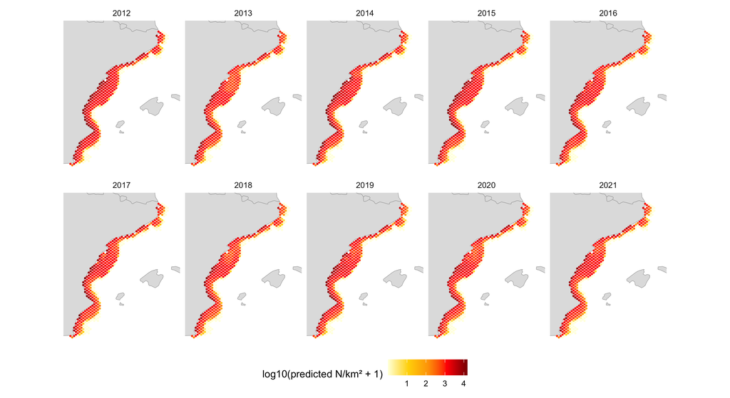

Figure 14: Predicted June red mullet density in GSA 6, 2012-2021.

```r
ggplot(mull.pred6) + land +
  geom_point(aes(grid.X, grid.Y, colour = log10(fit + 1)), size = 0.45) +
  scale_colour_gradientn(colours = c("lightyellow", "gold", "orange", "red", "darkred"),
                         name = "log10(predicted N/km² + 1)") +
  gsa6_view + facet_wrap(~year, ncol = 5) + theme_map
```

**Compute habitat change 2015-2021, with and without effort changes**

```r
mull.change6 <- mull.pred6 |>
  filter(year %in% c(2015, 2021)) |>
  select(grid.id, grid.X, grid.Y, year, fit, fit_env) |>
  pivot_wider(names_from = year, values_from = c(fit, fit_env)) |>
  mutate(perc.change     = 100 * (fit_2021 / fit_2015 - 1),
         perc.change.env = 100 * (fit_env_2021 / fit_env_2015 - 1))

write.csv(mull.change6, "outputs/MULLBAR_change_GSA6.csv", row.names = FALSE)
```

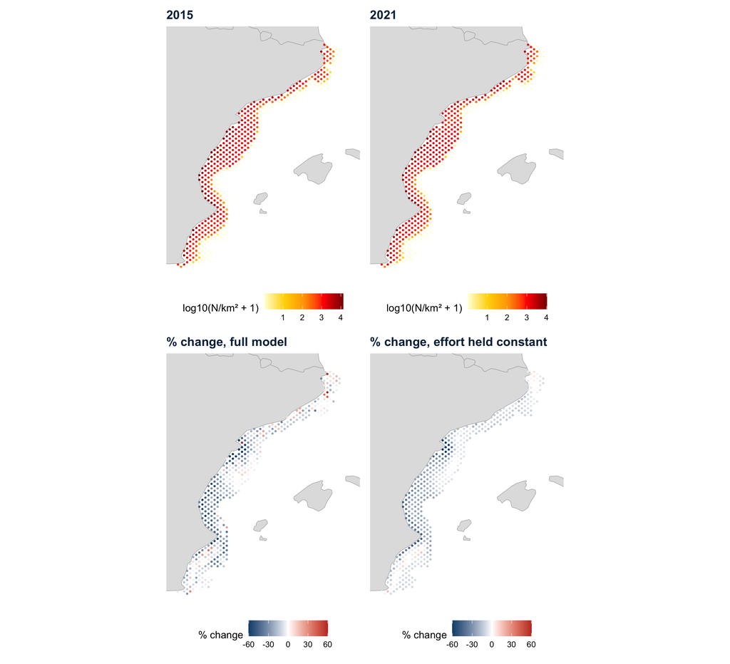

Figure 15: Predicted red mullet density in 2015 and 2021, and percentage change 2015-2021 from the full model and with fishing effort held constant.

```r
pct_lim <- quantile(abs(c(mull.change6$perc.change, mull.change6$perc.change.env)),
                    0.98, na.rm = TRUE)
dens_scale <- scale_colour_gradientn(colours = c("lightyellow", "gold", "orange", "red", "darkred"),
                                     name = "log10(N/km² + 1)")
pct_scale <- scale_colour_gradient2(low = pal_ocean[["mid"]], mid = "white", high = pal_ocean[["alert"]],
                                    midpoint = 0, limits = c(-pct_lim, pct_lim), oob = squish,
                                    name = "% change")
base_map <- function(var) ggplot(mull.change6) + land +
  geom_point(aes(grid.X, grid.Y, colour = .data[[var]]), size = 0.5) + gsa6_view + theme_map

mull.change6 <- mutate(mull.change6, d2015 = log10(fit_2015 + 1), d2021 = log10(fit_2021 + 1))

(base_map("d2015") + dens_scale + labs(title = "2015") +
 base_map("d2021") + dens_scale + labs(title = "2021")) /
(base_map("perc.change") + pct_scale + labs(title = "% change, full model") +
 base_map("perc.change.env") + pct_scale + labs(title = "% change, effort held constant"))
```

Across the 416 shelf and upper-slope cells predicted in both years, the median change in red mullet density from 2015 to 2021 is -12% with the full model and -12% with fishing effort held constant. With effort held constant, 92% of cells decline and changes range from -77% to 16%. The full model gives the same median but a much wider range (up to 767% in a few cells), which comes from year-to-year changes in recorded effort rather than in the environment. Declines are widespread along the central and southern coast of the GSA.

> **Discussion point: what drives the decline.** The effort-held-constant change reflects only bottom temperature, salinity and chlorophyll, but not which of them. Mean bottom temperature on the prediction grid is similar in 2015 and 2021, so the decline is not simply a warming signal. Partial predictions varying one covariate at a time, and a check against the observed MEDITS trend, would show which term drives it. Using two single years also makes the change sensitive to the conditions in those particular Junes. A trend over 2015-2021 would be more robust. The 2012 predictions are the highest of the series because 2012 hauls carry near-zero recorded effort, another reason to start in 2015.

## 2c. Red mullet: the group’s spatio-temporal model (GSA 6 and Adriatic)

On the morning of 21 October the working group extended the red mullet analysis to a second area, the Adriatic (GSAs 17-18), and moved to a spatio-temporal species distribution model. This section presents that work from the files shared in the group’s `shared_data` folder. The model structure was first reconstructed from the saved predictions (see Section 2c.2); the fitted model objects shared later in the afternoon (`fit_6.rds`, `fit_1718.rds`) confirm it and give the goodness of fit (see Section 2c.3). The data-preparation script has not been shared yet.

### 2c.1 Aims and data decisions

The group’s aims were to describe red mullet biomass in space and time in both areas, express habitat suitability on a 0-1 scale, and later relate it to marine heatwaves and fishing effort. Three decisions shape the analysis:

- **Response:** biomass per unit area (kg/km²), rather than numbers as in Section 2b.
- **Period 2014-2021:** 2012-2013 are excluded because there was no Croatian MEDITS survey in those years. This also avoids the early AIS ramp-up of Step 1.
- **Environment at each haul:** bottom temperature, salinity and oxygen and SST, matched to the nearest Copernicus point.

**Load the group’s haul tables and predictions (data/group/, from shared_data)**

```r
grp_dir <- "data/group"
mb_g  <- bind_rows(readRDS(file.path(grp_dir, "MB_6.rds")),
                   readRDS(file.path(grp_dir, "MB_1718.rds"))) |>
  filter(validity == "V") |>
  mutate(region = if_else(area == 6, "GSA 6", "GSAs 17-18"))
pred_g <- bind_rows(readRDS(file.path(grp_dir, "pred_6.rds"))    |> mutate(region = "GSA 6"),
                    readRDS(file.path(grp_dir, "pred_1718.rds")) |> mutate(region = "GSAs 17-18"))

hauls_g <- mb_g |> count(region, year) |>
  pivot_wider(names_from = year, values_from = n)
```

**Valid hauls per year in the group’s datasets**

```r
kable(hauls_g |> rename(Area = region))
```

Table 10: Number of valid MEDITS hauls (validity = V) per year in the group’s red mullet datasets. Area: GSA 6 (northern Spain) or GSAs 17-18 (Adriatic). Year columns: number of hauls in that year.

| Area | 2014 | 2015 | 2016 | 2017 | 2018 | 2019 | 2020 | 2021 |
| --- | --- | --- | --- | --- | --- | --- | --- | --- |
| GSA 6 | 81 | 79 | 83 | 84 | 83 | 85 | 39 | 83 |
| GSAs 17-18 | 203 | 287 | 279 | 61 | 224 | 156 | 181 | 240 |

The two datasets hold 617 and 1,631 valid hauls. Red mullet is absent from 17% of GSA 6 hauls and 11% of Adriatic hauls. Two years are thinly sampled: GSA 6 in 2020 (39 hauls, COVID-19) and the Adriatic in 2017 (61 hauls, a known data issue in the *Recap*).

### 2c.2 How the model was reconstructed

The prediction files contain, for each 1/24° grid cell (about 16 km²) and year, the columns `est`, `est_non_rf`, `est_rf`, `omega_s`, `epsilon_st` and `dens`. This is the standard prediction output of the R package **sdmTMB**: a log-link model whose linear predictor `est` is the sum of fixed effects (`est_non_rf`), a spatial random field constant over years (`omega_s`) and a spatio-temporal random field that varies by year (`epsilon_st`), with `dens = exp(est)`. All of these identities hold exactly in both files.

**Recover the fixed effects from the predictions**

```r
fe <- pred_g |>
  group_by(region) |>
  group_modify(~ {
    m <- lm(est_non_rf ~ depth + sbt, data = .x)
    tibble(`Intercept` = coef(m)[1], `Depth (per m)` = coef(m)[2],
           `Bottom temp. (per °C)` = coef(m)[3], `R²` = summary(m)$r.squared)
  }) |> ungroup()

kable(fe |> mutate(across(where(is.numeric), \(x) round(x, 4))) |> rename(Area = region))
```

Table 11: Fixed effects recovered from the group’s predictions: linear regression of the fixed-effect part of the linear predictor (est_non_rf, log biomass) on depth and bottom temperature, over all grid cells and years. Area: GSA 6 or GSAs 17-18. Intercept: est_non_rf at 0 m depth and 0 °C. Depth (per m): change in log biomass per metre of depth. Bottom temp. (per °C): change in log biomass per °C of bottom temperature. R²: share of the variance of est_non_rf explained (1 = exact).

| Area | Intercept | Depth (per m) | Bottom temp. (per °C) | R² |
| --- | --- | --- | --- | --- |
| GSA 6 | 0.9283 | -0.0289 | 0.1668 | 1 |
| GSAs 17-18 | -1.5373 | -0.0114 | 0.1587 | 1 |

A linear function of depth and bottom temperature reproduces the fixed-effect predictions exactly (R² = 1) in both areas, with no separate year effect. On the response scale, biomass falls by 94% per 100 m of depth in GSA 6 and by 68% in the Adriatic, and rises by 18% and 17% per +1 °C of bottom temperature. Year-to-year change therefore comes only from bottom temperature and the spatio-temporal field. The observation family and the mesh are not recoverable from the predictions.

### 2c.3 Fitted models and goodness of fit

**Load the group’s fitted models and refit them with the installed sdmTMB**

```r
library(sdmTMB)
grp_fits <- list(`GSA 6` = readRDS(file.path("data/group", "fit_6.rds")),
                 `GSAs 17-18` = readRDS(file.path("data/group", "fit_1718.rds")))

refit <- function(f) {
  d <- f$data[complete.cases(f$data[, c("biomass_kgkm2", "sbt", "depth")]), ]
  mesh <- make_mesh(d, xy_cols = f$spde$xy_cols, mesh = f$spde$mesh)   # same mesh, hauls with complete covariates
  sdmTMB(f$formula[[1]], data = d, mesh = mesh, time = "year",
         family = tweedie(link = "log"), spatial = "on", spatiotemporal = "ar1")
}
grp_m <- lapply(grp_fits, refit)

set.seed(1)
grp_res <- bind_rows(lapply(names(grp_m), \(a) {
  m <- grp_m[[a]]
  tibble(region = a, obs = m$data$biomass_kgkm2,
         fitted = exp(predict(m)$est),
         resid = residuals(m, type = "mle-mvn"))
}))
```

**Model summary by area**

```r
fit_row <- function(a) {
  m <- grp_m[[a]]; o <- grp_fits[[a]]   # estimates from the group's shared fit; convergence checked on the refit
  fe <- tidy(o, conf.int = TRUE); rp <- tidy(o, "ran_pars", conf.int = TRUE)
  g <- function(t, x = "estimate") rp[[x]][rp$term == t]
  tibble(Area = a,
         Hauls = nrow(m$data), `Mesh vertices` = m$spde$mesh$n,
         `Bottom temp. (per SD)` = sprintf("%.2f [%.2f, %.2f]", fe$estimate[1], fe$conf.low[1], fe$conf.high[1]),
         `Depth (per SD)` = sprintf("%.2f [%.2f, %.2f]", fe$estimate[2], fe$conf.low[2], fe$conf.high[2]),
         `Range (km)` = round(g("range")), `σ ω` = round(g("sigma_O"), 2), `σ ε` = round(g("sigma_E"), 2),
         `AR(1) ρ` = round(g("rho"), 2), `Tweedie p` = round(g("tweedie_p"), 2),
         `Converged` = if (all(unlist(sanity(m, silent = TRUE)))) "yes" else "check")
}
grp_fit_tab <- bind_rows(lapply(names(grp_m), fit_row))
kable(grp_fit_tab)
```

Table 12: Summary of the group’s sdmTMB models by area. Hauls: hauls used in the fit. Mesh vertices: number of vertices of the SPDE mesh on which the random fields are estimated. Bottom temp. (per SD), Depth (per SD): fixed-effect coefficients on the log scale per standard deviation of the covariate (the model uses scaled covariates), with 95% confidence intervals. Range (km): distance at which the spatial correlation drops to about 0.13. σ ω: standard deviation of the spatial random field (log scale). σ ε: standard deviation of the spatio-temporal random field (log scale). AR(1) ρ: correlation of the spatio-temporal field between consecutive years. Tweedie p: Tweedie power parameter (between 1 and 2). Converged: all sdmTMB sanity() checks passed.

| Area | Hauls | Mesh vertices | Bottom temp. (per SD) | Depth (per SD) | Range (km) | σ ω | σ ε | AR(1) ρ | Tweedie p | Converged |
| --- | --- | --- | --- | --- | --- | --- | --- | --- | --- | --- |
| GSA 6 | 617 | 184 | 0.12 [-0.03, 0.26] | -1.78 [-2.15, -1.41] | 86 | 3.07 | 0.36 | 0.06 | 1.38 | yes |
| GSAs 17-18 | 1965 | 414 | 0.48 [0.40, 0.57] | -0.64 [-0.76, -0.53] | 151 | 1.57 | 1.36 | 0.26 | 1.68 | yes |

Both models converge cleanly (positive-definite Hessian, small gradients, all `sanity()` checks passed). Coefficients are on the scale of standardised covariates (per standard deviation), with 95% confidence intervals.

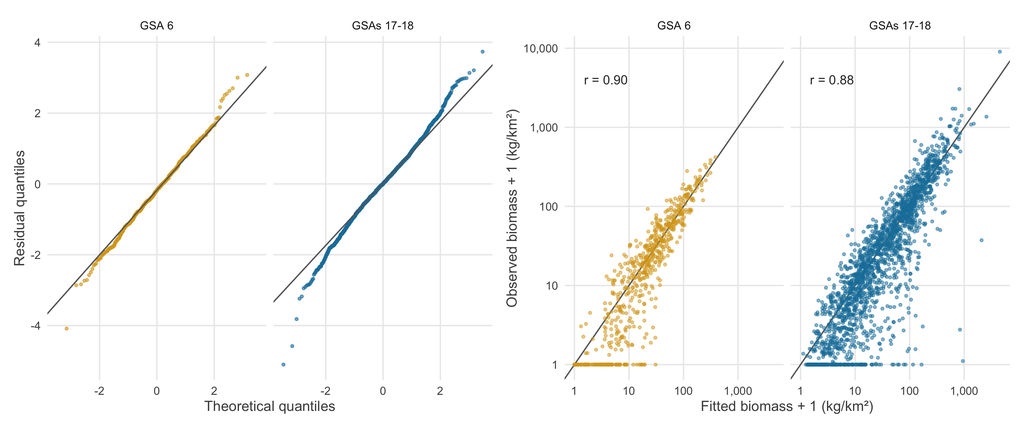

Figure 16: Goodness of fit of the group’s models. Left: randomised quantile residuals (sdmTMB ‘mle-mvn’ residuals, using one draw of the random effects) against the normal distribution; points on the line indicate a well-specified observation model. Right: observed against fitted biomass at each haul (log scale), with the 1:1 line.

```r
grp_cols <- c(`GSA 6` = "#d9a520", `GSAs 17-18` = pal_ocean[["surface"]])
p_qq <- ggplot(grp_res, aes(sample = resid, colour = region)) +
  stat_qq(size = 0.8, alpha = 0.6) + stat_qq_line(colour = "grey40") +
  facet_wrap(~region) + scale_colour_manual(values = grp_cols, guide = "none") +
  labs(x = "Theoretical quantiles", y = "Residual quantiles") + theme_ocean()
grp_cor <- grp_res |> group_by(region) |>
  summarise(r = cor(log1p(obs), log1p(fitted)), .groups = "drop")
p_of <- ggplot(grp_res, aes(fitted + 1, obs + 1, colour = region)) +
  geom_abline(colour = "grey40") + geom_point(size = 0.8, alpha = 0.5) +
  geom_text(data = grp_cor, aes(x = 1.5, y = 4000, label = sprintf("r = %.2f", r)),
            hjust = 0, colour = "grey20", size = 3.5, inherit.aes = FALSE) +
  scale_x_log10(labels = label_comma()) + scale_y_log10(labels = label_comma()) +
  facet_wrap(~region) + scale_colour_manual(values = grp_cols, guide = "none") +
  labs(x = "Fitted biomass + 1 (kg/km²)", y = "Observed biomass + 1 (kg/km²)") + theme_ocean()
p_qq | p_of
```

> **Discussion point: possible misalignment in the Adriatic fit.** The Adriatic data hold 17 hauls with missing bottom temperature. The mesh was built on all 1982 hauls, but the model drops the incomplete ones, so after the first missing value the hauls and their mesh locations can fall out of step. Refitting on complete hauls with the same mesh gives a stronger temperature effect (0.8 per SD instead of 0.48). The coefficients reported here are the group’s; the residual checks use the refit. Building the mesh after removing incomplete hauls would fix this.

Residuals follow the normal line closely in both areas, so the Tweedie observation model fits the zeros and the skewed catches well. Fitted and observed biomass are strongly correlated (r = 0.9 in GSA 6 and 0.88 in the Adriatic, on the log scale). These are in-sample fits that include the random fields, so they describe how well the model reproduces the data rather than how well it predicts new hauls; a cross-validation (`sdmTMB_cv()`) would test the latter.

#### 2c.3.1 Effect of bottom temperature in the two areas

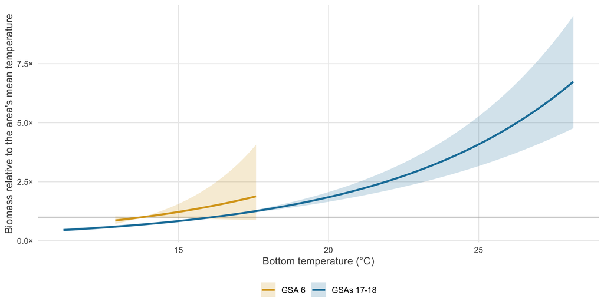

Figure 17: Effect of bottom temperature on red mullet biomass in the group’s models: predicted biomass relative to the mean bottom temperature of each area’s hauls, at constant depth, with 95% confidence bands, over the range of bottom temperatures sampled in each area.

```r
temp_eff <- bind_rows(lapply(names(grp_m), \(a) {
  m <- grp_m[[a]]; fe <- tidy(grp_fits[[a]])
  mu <- mean(m$data$sbt); sdv <- sd(m$data$sbt)
  b <- fe$estimate[1] / sdv; se <- fe$std.error[1] / sdv
  tibble(region = a, sbt = seq(min(m$data$sbt), max(m$data$sbt), length.out = 100)) |>
    mutate(d = sbt - mu, rel = exp(b * d),
           lo = exp(b * d - 1.96 * se * abs(d)), hi = exp(b * d + 1.96 * se * abs(d)))
}))
grp_temp <- bind_rows(lapply(names(grp_m), \(a) {
  m <- grp_m[[a]]; fe <- tidy(grp_fits[[a]], conf.int = TRUE); sdv <- sd(m$data$sbt)
  tibble(region = a, per_c = exp(fe$estimate[1] / sdv) - 1,
         lo = exp(fe$conf.low[1] / sdv) - 1, hi = exp(fe$conf.high[1] / sdv) - 1,
         sbt_min = min(m$data$sbt), sbt_max = max(m$data$sbt))
}))

ggplot(temp_eff, aes(sbt, rel, colour = region, fill = region)) +
  geom_hline(yintercept = 1, colour = "grey70") +
  geom_ribbon(aes(ymin = lo, ymax = hi), alpha = 0.2, colour = NA) +
  geom_line(linewidth = 1) +
  scale_colour_manual(values = grp_cols, name = NULL) + scale_fill_manual(values = grp_cols, name = NULL) +
  scale_y_continuous(labels = label_number(suffix = "×")) +
  labs(x = "Bottom temperature (°C)", y = "Biomass relative to the area's mean temperature") + theme_ocean()
```

**Bottom temperature effect per °C**

```r
kable(grp_temp |> transmute(Area = region,
                            `Change in biomass per +1 °C` = sprintf("%s [%s, %s]", percent(per_c, 1), percent(lo, 1), percent(hi, 1)),
                            `Sampled bottom temperature (°C)` = sprintf("%.1f-%.1f", sbt_min, sbt_max)))
```

Table 13: Effect of bottom temperature on red mullet biomass in the group’s models. Area: GSA 6 or GSAs 17-18. Change in biomass per +1 °C: percentage change in predicted biomass for a 1 °C increase in bottom temperature at constant depth, with 95% confidence interval (the per-SD coefficient divided by the standard deviation of bottom temperature across the hauls). Sampled bottom temperature (°C): range of bottom temperature across the hauls of each area.

| Area | Change in biomass per +1 °C | Sampled bottom temperature (°C) |
| --- | --- | --- |
| GSA 6 | 18% [-4%, 45%] | 12.9-17.6 |
| GSAs 17-18 | 17% [14%, 21%] | 11.2-28.2 |

Bottom temperature has a clear positive effect in the Adriatic: biomass rises by 17% per +1 °C, and the confidence interval is well above zero. In GSA 6 the estimate is similar per degree (18%), but the interval includes zero, so the effect is not significant there. GSA 6 hauls span a much narrower range of bottom temperatures (12.9-17.6 °C against 11.2-28.2 °C), which limits how well the effect can be estimated, and depth dominates there.

> **Discussion point: no intercept.** The formula `0 + scale(sbt) + scale(depth)` has no intercept, so the mean level of log biomass has to be absorbed by the spatial random field. This inflates the spatial field (σ ω = 3.07 in GSA 6) and makes ω harder to interpret as hotspots. Adding the intercept (or a year factor, `0 + as.factor(year) + ...`, the usual choice for an index) is recommended.

### 2c.4 Predicted biomass

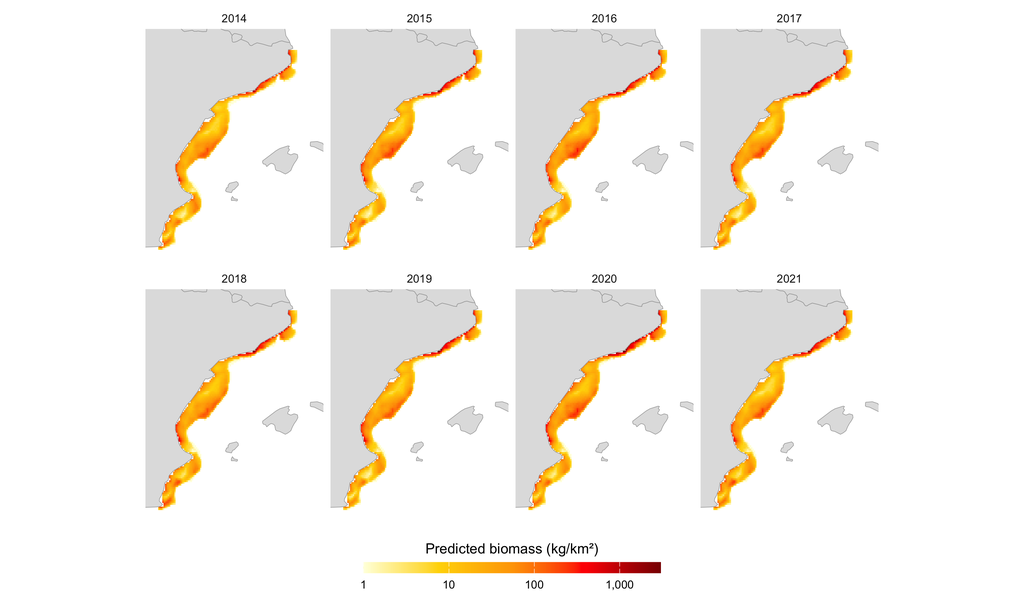

Figure 18: Predicted red mullet biomass in GSA 6, 2014-2021, from the group’s sdmTMB model.

```r
ggplot() + tile(filter(pred_g, region == "GSA 6"), "dens") + land +
  dens_fill + bar_wide + gsa6_view + facet_wrap(~year, ncol = 4) + theme_map
```

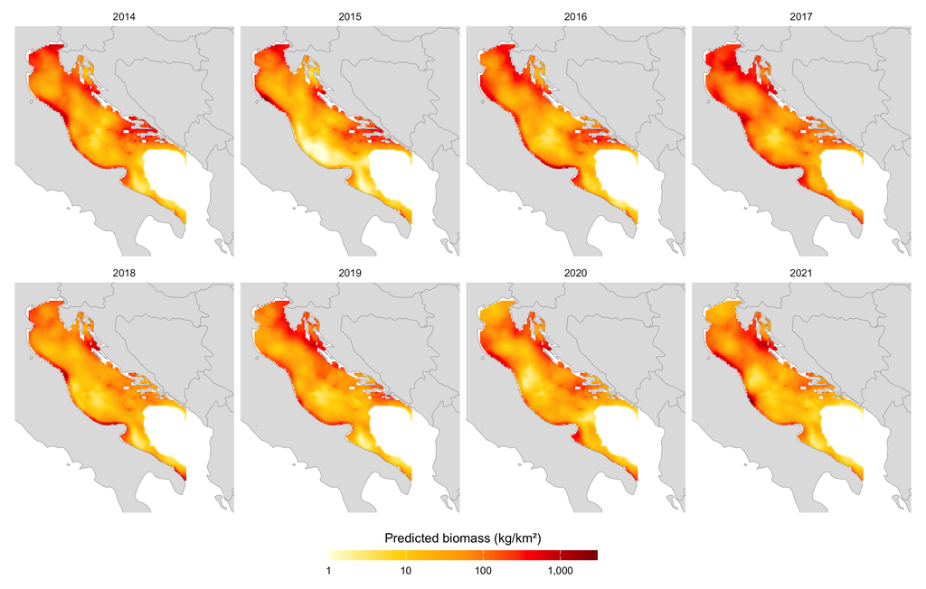

Figure 19: Predicted red mullet biomass in GSAs 17-18 (Adriatic), 2014-2021, from the group’s sdmTMB model.

```r
ggplot() + tile(filter(pred_g, region == "GSAs 17-18"), "dens") + land +
  dens_fill + bar_wide + adr_view + facet_wrap(~year, ncol = 4) + theme_map
```

In GSA 6, predicted biomass is highest on the inner shelf along the whole coast and drops quickly offshore, matching the depth pattern of Section 2b. In the Adriatic, biomass is highest in the shallow northern basin and along the Croatian coast and lower in the deeper central and southern basin, a gentler gradient that reflects the weaker depth effect and the much wider shelf.

### 2c.5 Spatial and spatio-temporal random effects

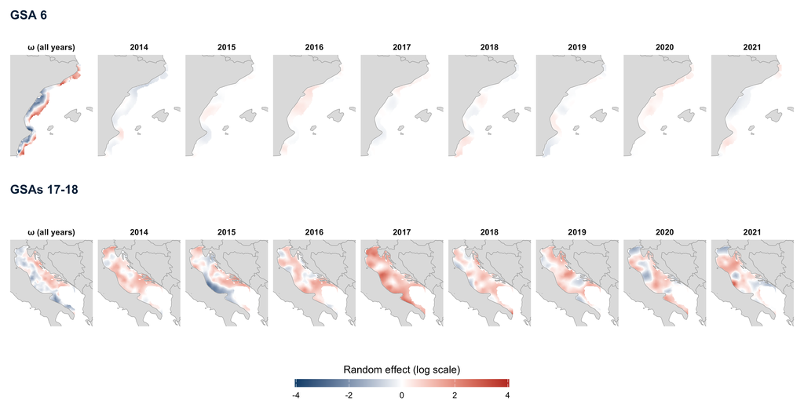

Figure 20: Random effects of the group’s model. First column: spatial random field (ω), constant over years, centred within each area; persistent hotspots (red) and coldspots (blue) of biomass not explained by depth and bottom temperature. Other columns: spatio-temporal random field (ε) by year, the departure from that persistent pattern in each year. One colour scale for all panels.

```r
re_long <- bind_rows(
  pred_g |> filter(year == 2014) |> group_by(region) |>
    mutate(value = omega_s - mean(omega_s), panel = "ω (all years)") |> ungroup(),
  pred_g |> mutate(value = epsilon_st, panel = as.character(year))
) |> mutate(panel = factor(panel, c("ω (all years)", as.character(2014:2021))))

re_lim <- max(abs(re_long$value))
re_scale <- scale_fill_gradient2(low = pal_ocean[["mid"]], mid = "white", high = pal_ocean[["alert"]],
                                 midpoint = 0, limits = c(-re_lim, re_lim),
                                 name = "Random effect (log scale)")
re_map <- function(reg, view) {
  ggplot() + tile(filter(re_long, region == reg), "value") + land + re_scale + view +
    facet_wrap(~panel, nrow = 1) + labs(title = reg) + theme_map +
    theme(strip.text = element_text(face = "bold"))
}

re_map("GSA 6", gsa6_view) / re_map("GSAs 17-18", adr_view) +
  plot_layout(guides = "collect") & theme(legend.position = "bottom") & bar_wide
```

The spatio-temporal field is small in GSA 6 (ε between -0.74 and 0.56) but large in the Adriatic (-2.78 to 2.92), where a value of ±2.9 multiplies local biomass by up to about 18. In GSA 6, most of the spatial structure is persistent (ω, first column) rather than year-specific: ω spans 7.5 log units across the area, against 1.3 for ε. In the Adriatic, the year-specific field is as large as the persistent one.

### 2c.6 Biomass index

Summing predicted biomass over all grid cells gives an annual index of total red mullet biomass in each area.

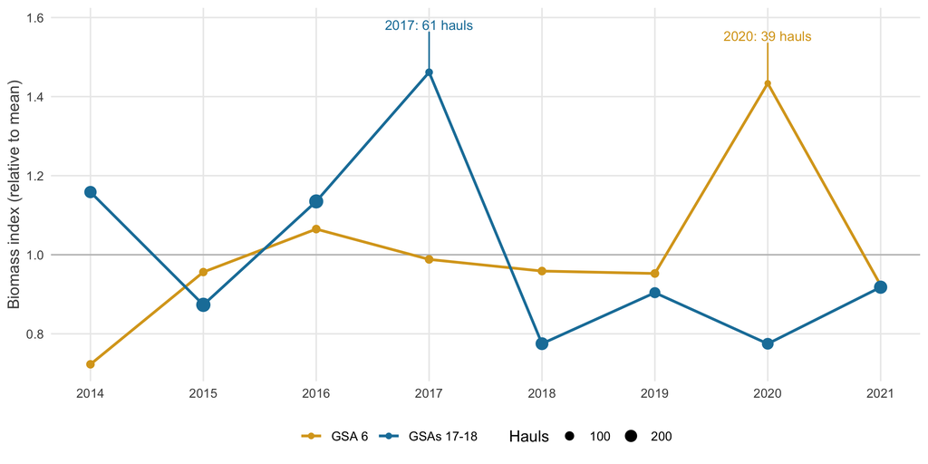

Figure 21: Annual biomass index (sum of predicted biomass × cell area), relative to each area’s 2014-2021 mean. Point size shows the number of hauls; the two thinly sampled years are labelled.

```r
idx_g <- pred_g |>
  group_by(region, year) |>
  summarise(biomass_t = sum(dens * cell_km2) / 1000, .groups = "drop") |>
  group_by(region) |> mutate(rel = biomass_t / mean(biomass_t)) |> ungroup() |>
  left_join(count(mb_g, region, year, name = "hauls"), by = c("region", "year"))
thin <- idx_g |> group_by(region) |> slice_min(hauls, n = 1)

ggplot(idx_g, aes(year, rel, colour = region)) +
  geom_hline(yintercept = 1, colour = "grey75") +
  geom_line(linewidth = 0.9) + geom_point(aes(size = hauls)) +
  ggrepel::geom_text_repel(data = thin, aes(label = paste0(year, ": ", hauls, " hauls")),
                           size = 3.3, nudge_y = 0.12, show.legend = FALSE, seed = 1) +
  scale_colour_manual(values = c(`GSA 6` = "#d9a520", `GSAs 17-18` = pal_ocean[["surface"]]), name = NULL) +
  scale_size_area(max_size = 4, name = "Hauls") +
  scale_x_continuous(breaks = 2014:2021) +
  labs(x = NULL, y = "Biomass index (relative to mean)") + theme_ocean()
```

The GSA 6 index stays within ±28% of its mean in every year except 2020, and changes by -3% between 2015 and 2021. The Tweedie GAM of Section 2b gives a median change in density of -12% over the same years: the two models differ in response (biomass vs numbers), period and structure, but neither suggests an increase in GSA 6. The Adriatic index fluctuates more, between 77% and 146% of its mean.

> **Discussion point: index peaks in thinly sampled years.** The highest index in each area falls in its least-sampled year: GSA 6 in 2020 and the Adriatic in 2017. With few hauls, the spatio-temporal field for that year is poorly constrained, so these peaks may reflect sampling rather than biomass. sdmTMB’s `get_index()` returns the index with standard errors, which would show how uncertain these years are; now that the fitted models are shared, this is the next step.

> **Discussion point: extrapolation in GSA 6.** The GSA 6 prediction grid reaches 11 m depth and 22.2 °C bottom temperature, while the hauls cover 35-300 m and at most 17.6 °C. With linear, positive temperature and negative depth effects, the shallowest, warmest coastal cells get the highest predicted biomass by extrapolation: cells shallower than the shallowest haul make up 12% of the GSA 6 grid but hold 34% of its predicted biomass. This is the same issue as for total fish in Section 2a; restricting the prediction grid to the sampled depth range would avoid it.

### 2c.7 Habitat suitability index

The group’s final aim was a 0-1 habitat suitability index (HSI), mapped for both areas. The way it was rescaled is not documented, but rescaling the fixed-effect part of the model (depth and bottom temperature, `est_non_rf`) to 0-1 across all years within each area reproduces the group’s maps closely, so that definition is used here. Because it uses the environmental effects only, the HSI describes where conditions suit red mullet, not the persistent hotspots captured by ω.

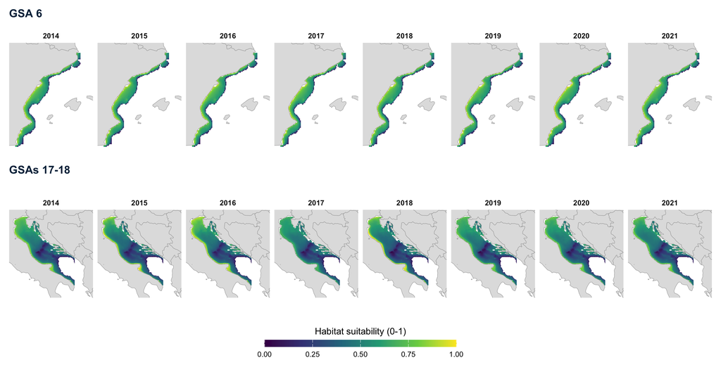

Figure 22: Habitat suitability index for red mullet, 2014-2021: fixed-effect predictions (depth and bottom temperature) of the group’s model rescaled to 0-1 across all years within each area. Reproduces the group’s own HSI maps for both areas.

```r
hsi_g <- pred_g |>
  group_by(region) |>
  mutate(hsi = (est_non_rf - min(est_non_rf)) / (max(est_non_rf) - min(est_non_rf))) |>
  ungroup()
hsi_scale <- scale_fill_viridis_c(limits = c(0, 1), name = "Habitat suitability (0-1)")
hsi_map <- function(reg, view) {
  ggplot() + tile(filter(hsi_g, region == reg), "hsi") + land + hsi_scale + view +
    facet_wrap(~year, nrow = 1) + labs(title = reg) + theme_map +
    theme(strip.text = element_text(face = "bold"))
}

hsi_map("GSA 6", gsa6_view) / hsi_map("GSAs 17-18", adr_view) +
  plot_layout(guides = "collect") & theme(legend.position = "bottom") & bar_wide
```

**Mean habitat suitability by year**

```r
kable(hsi_g |> group_by(Area = region, year) |> summarise(hsi = round(mean(hsi), 2), .groups = "drop") |>
        pivot_wider(names_from = year, values_from = hsi))
```

Table 14: Mean habitat suitability index (HSI) by area and year. Area: GSA 6 or GSAs 17-18. Year columns: average over all prediction grid cells of the HSI, the fixed-effect predictions (depth and bottom temperature) rescaled to 0-1 across all years within each area (0 = least suitable, 1 = most suitable).

| Area | 2014 | 2015 | 2016 | 2017 | 2018 | 2019 | 2020 | 2021 |
| --- | --- | --- | --- | --- | --- | --- | --- | --- |
| GSA 6 | 0.60 | 0.60 | 0.6 | 0.60 | 0.60 | 0.61 | 0.61 | 0.60 |
| GSAs 17-18 | 0.49 | 0.47 | 0.5 | 0.45 | 0.45 | 0.47 | 0.47 | 0.47 |

Suitability is highest on the shallow inner shelf in both areas. In the Adriatic, the warm, shallow northern basin scores high almost everywhere, while the deeper south scores low. Year-to-year differences come only from bottom temperature, since depth is fixed.

> **Still to share:** the data-preparation script that builds `MB_*.rds` and the effort and prediction grids, and confirmation of the HSI rescaling. With the fitted models now shared, the index uncertainty can be computed with `get_index()`.

### 2c.8 Change in habitat suitability, 2014 to 2021

**Percentage change in HSI, 2014 to 2021**

```r
hsi_chg <- hsi_g |>
  filter(year %in% c(2014, 2021)) |>
  select(region, X, Y, year, hsi) |>
  pivot_wider(names_from = year, values_from = hsi, names_prefix = "hsi_") |>
  mutate(perc = 100 * (hsi_2021 - hsi_2014) / hsi_2014,
         diff = hsi_2021 - hsi_2014)
pc_rng <- function(reg) with(filter(hsi_chg, region == reg),
                             paste0(round(min(perc)), "% to +", round(max(perc)), "%"))
```

The group’s own HSI maps for each year, shown below, match the reproduction in Figure 22. From these, the group mapped the percentage change in each cell between the first and last year, (2021 − 2014) / 2014 × 100. The change maps are not labelled with the variable, but computing this change on the HSI reproduces them: the Adriatic range (-19% to +69%) matches the group’s legend, and GSA 6 matches except for a few cells where the HSI is close to zero.

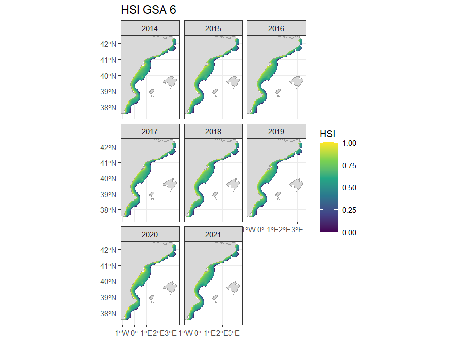

(a) GSA 6

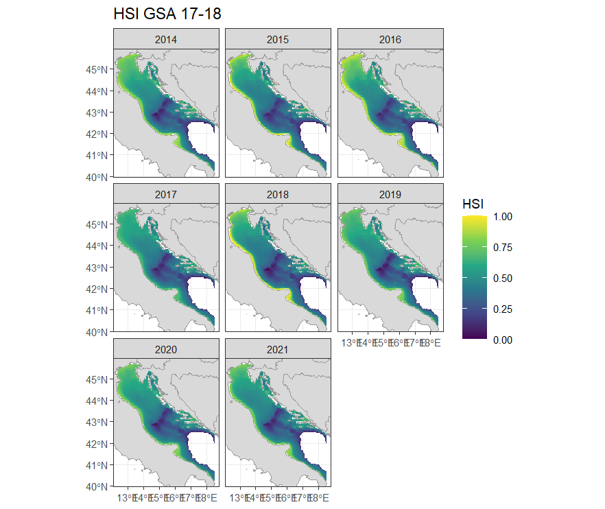

(b) GSAs 17-18 (Adriatic)

Figure 23: The group’s habitat suitability maps, 2014-2021.

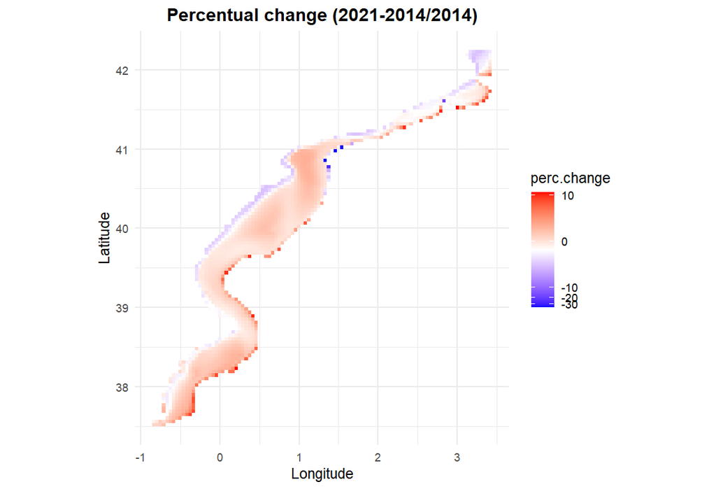

(a) GSA 6

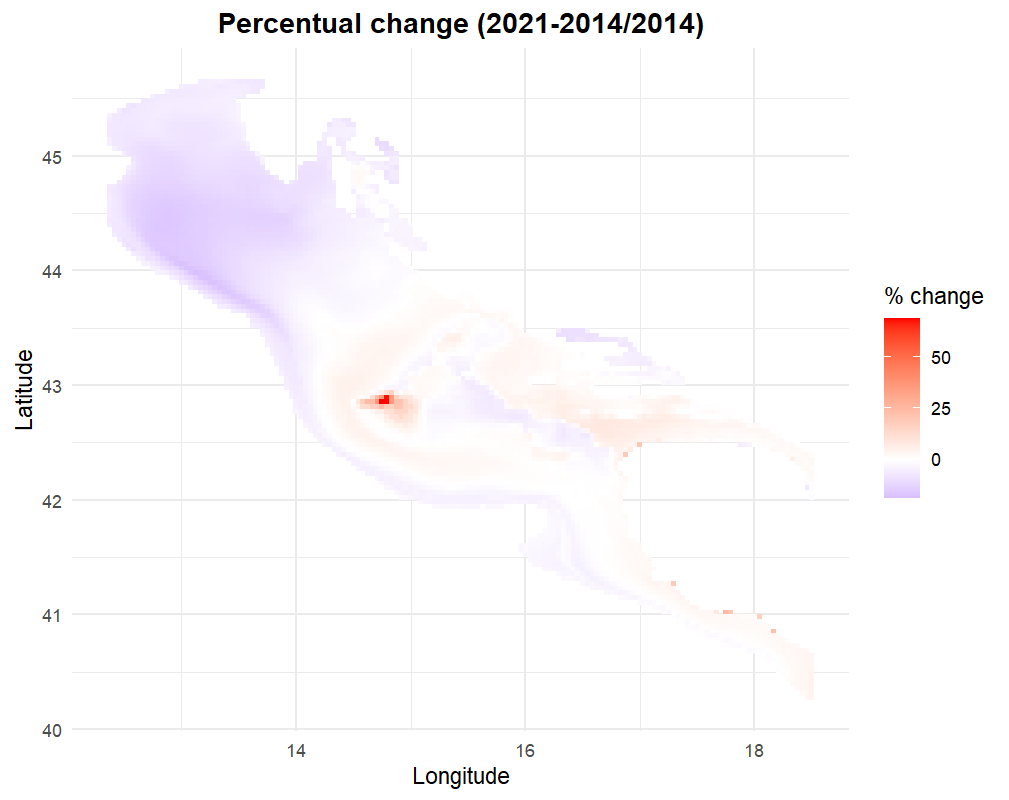

(b) GSAs 17-18 (Adriatic)

Figure 24: The group’s maps of percentage change in habitat suitability between 2014 and 2021. Red: higher suitability in 2021; blue: lower. Each map has its own colour scale.

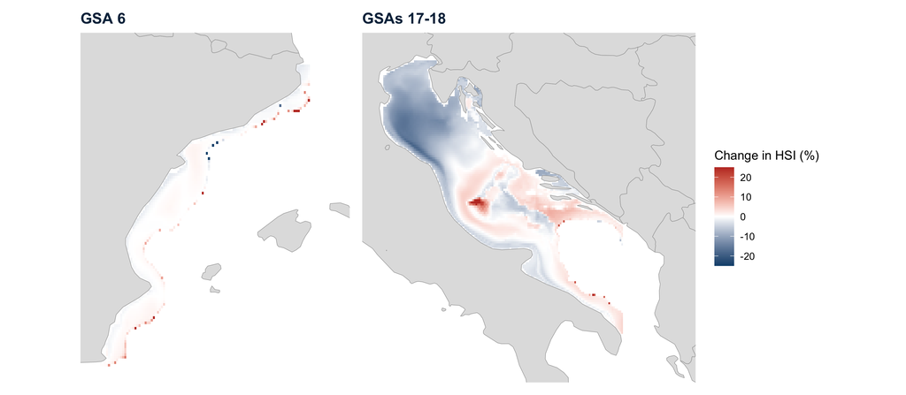

Figure 25: Percentage change in habitat suitability between 2014 and 2021, both areas on the same colour scale (capped at ±25%; a few cells exceed it).

```r
chg_map <- function(var, reg, view, lim, name) {
  ggplot() + tile(filter(hsi_chg, region == reg), var) + land + view +
    scale_fill_gradient2(low = pal_ocean[["mid"]], mid = "white", high = pal_ocean[["alert"]],
                         midpoint = 0, limits = c(-lim, lim), oob = squish, name = name) +
    labs(title = reg) + theme_map
}
(chg_map("perc", "GSA 6", gsa6_view, 25, "Change in HSI (%)") |
   chg_map("perc", "GSAs 17-18", adr_view, 25, "Change in HSI (%)")) +
  plot_layout(guides = "collect") & theme(legend.position = "right")
```

**Summary of the change by area**

```r
kable(hsi_chg |> group_by(Area = region) |>
        summarise(Cells = n(),
                  `Median change (%)` = round(median(perc), 1),
                  `Cells with lower HSI` = percent(mean(diff < 0), 1),
                  `Median difference (HSI points)` = round(median(diff), 3),
                  `Largest drop (HSI points)` = round(min(diff), 2)))
```

Table 15: Change in habitat suitability (HSI, 0-1) between 2014 and 2021 by area. Cells: number of prediction grid cells. Median change (%): median per-cell percentage change, (HSI 2021 − HSI 2014) / HSI 2014 × 100. Cells with lower HSI: share of cells where the HSI fell. Median difference (HSI points): median per-cell difference, HSI 2021 − HSI 2014, on the 0-1 scale. Largest drop (HSI points): most negative per-cell difference.

| Area | Cells | Median change (%) | Cells with lower HSI | Median difference (HSI points) | Largest drop (HSI points) |
| --- | --- | --- | --- | --- | --- |
| GSA 6 | 1485 | 0.1 | 42% | 0.001 | -0.02 |
| GSAs 17-18 | 5718 | -1.8 | 63% | -0.007 | -0.13 |

In GSA 6, suitability barely changes between 2014 and 2021 (median 0.1%): a slight gain over most of the shelf and slight losses along its shallow inner edge. In the Adriatic (median -1.8%), suitability falls slightly over most of the northern basin and rises slightly in the central and southern basin, with the strongest increase in a small patch of the central Adriatic (around 14.8°E, 42.9°N). As the HSI only contains depth and bottom temperature, these maps show where bottom temperature differed between the two years.

> **Discussion points.** (1) A percentage change of a 0-1 index rescaled to its minimum is unstable: where the 2014 HSI is close to zero, a tiny absolute change becomes a large percentage (up to 217% in a GSA 6 cell). The strongest increase in the Adriatic, the central patch, is the same case: in absolute HSI points it is small, while the loss over the northern basin, which has high suitability, is the larger change. The difference in HSI points (summarised in the table) is the more robust measure. (2) Comparing two single years mixes trend with year-to-year variability; a per-cell linear trend over 2014-2021 would be a better summary of change. (3) A fixed colour scale shared by both areas, and centred on zero, would make the group’s two maps directly comparable.

### 2c.9 Overlap between red mullet and trawling

The last step so far links the model to the fishery, the group’s next aim after the index and the HSI. The group mapped, for each year, a local correlation between red mullet and trawling effort: red where the two rise and fall together across neighbouring cells (trawling concentrates where red mullet is abundant), blue where they diverge.

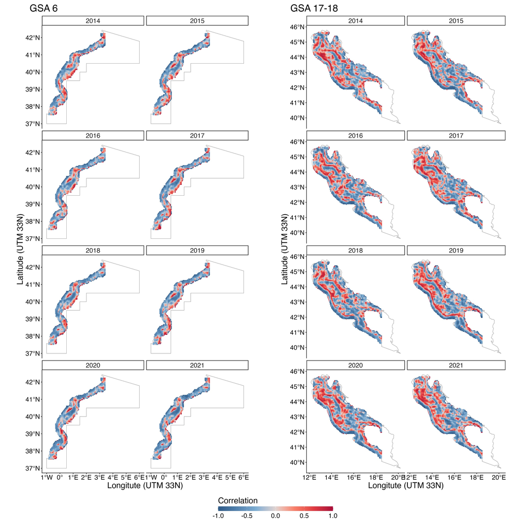

Figure 26: The group’s map of local correlation between red mullet and trawling effort, 2014-2021. Left: GSA 6. Right: GSAs 17-18 (Adriatic). Red: positive correlation; blue: negative. Original figure by the group.

The script for this map has not been shared. The group’s files include yearly trawling effort on the same grid as the predictions (`eff_grid_6.rds`, `eff_grid_1718.rds`: hours in the year, `trawl_y`, in the previous year, `trawl_y1`, and relative effort, `trawl_rel`). A moving-window Pearson correlation between predicted biomass (`dens`) and `trawl_y`, computed here as a check, gives the same broad pattern in the Adriatic: positive in the north-western and central basin and negative along the coastal edge. It does not match exactly, so the variables, window size and method remain to be confirmed.

In GSA 6, correlations are mostly negative, with positive patches on parts of the outer shelf. In the Adriatic, a band of positive correlation runs through the north-western and central basin in every year and is strongest in 2020-2021, while the coastal edge is negative throughout.

> **Discussion points.** (1) Within a small window, correlations close to ±1 are common by chance, so the map needs a significance test or a larger window before it is interpreted. (2) The predictions do not include effort, which is right for this question, but they include the spatial random fields, so part of the overlap may come from where hauls were taken. (3) Simpler, whole-area summaries of overlap would complement the map: for example, the share of trawling hours in the cells with the highest predicted biomass, or a per-cell correlation across the eight years. (4) The axis labels read “UTM 33N” but the coordinates are in degrees.

> **Still to share:** the script behind the correlation map (variables, window, method).

### 2c.10 Marine heatwaves, biomass trends and trawling trends

The group’s last step relates the red mullet model to marine heatwaves (MHWs) and to trawling. For each grid cell of the predictions, it combines three layers: summer heatwave exposure, the 2014-2021 linear trend in predicted biomass, and the 2014-2021 linear trend in trawling hours. The trends were computed by the group (`df_slope_6.rds`, `df_slope.rds`); they match exactly a per-cell linear regression of the predicted biomass (`pred_*.rds`) and of the yearly trawling hours (`eff_grid_*.rds`) on year.

The heatwave metrics are recomputed here for both areas on the prediction grid, with the method of Section 3 (Hobday et al. 2016, `heatwaveR`, summer events peaking in June-August). The group’s two scripts are included in the repository with relative paths (`scripts/5_MHW_grids.R`, adapted from `mhw_GSA6.R`; `scripts/6_MHW_trend_maps.R`, adapted from `Plot_MHW_BiologicalTrend_Effor_ttrend.R`).

**Compute heatwave metrics on both prediction grids (not evaluated: needs the daily SST NetCDF)**

```r
source("scripts/5_MHW_grids.R")   # writes outputs/MHW_grid_6.csv and outputs/MHW_grid_1718.csv
```

**Load the heatwave metrics and compare with the group’s Adriatic file**

```r
mhw_g <- bind_rows(read.csv("outputs/MHW_grid_6.csv") |> mutate(region = "GSA 6"),
                   read.csv("outputs/MHW_grid_1718.csv") |> mutate(region = "GSAs 17-18"))

# Check against the group's Adriatic metrics (MHW_gsa17.csv), cell by cell
mhw_chk <- read.csv("outputs/MHW_grid_1718.csv") |>
  mutate(X = round(X, 4), Y = round(Y, 4)) |>
  inner_join(read.csv("data/group/MHW_gsa17.csv", sep = ";") |>
               transmute(X = round(X, 4), Y = round(Y, 4), YEAR, group_cum = mhw_cum_intensity),
             by = c("X", "Y", "YEAR"))
mhw_same <- with(filter(mhw_chk, sst_available), mean(abs(mhw_cum_intensity - group_cum) < 1e-6))
mhw_nosst <- with(filter(mhw_chk, !sst_available), sum(YEAR == 2014))

mhw_year <- mhw_g |>
  group_by(region, YEAR) |>
  summarise(cum = mean(mhw_cum_intensity, na.rm = TRUE), days = mean(mhw_days, na.rm = TRUE),
            .groups = "drop")
```

For the Adriatic, the recomputed metrics are identical to the group’s file (`MHW_gsa17.csv`) in 99.6% of cell-years with SST data. The difference is in 509 cells (9% of the grid), almost all north of 45.0°N, where the SST product has no data: the group’s file gives them zero heatwaves, while here they are left missing.

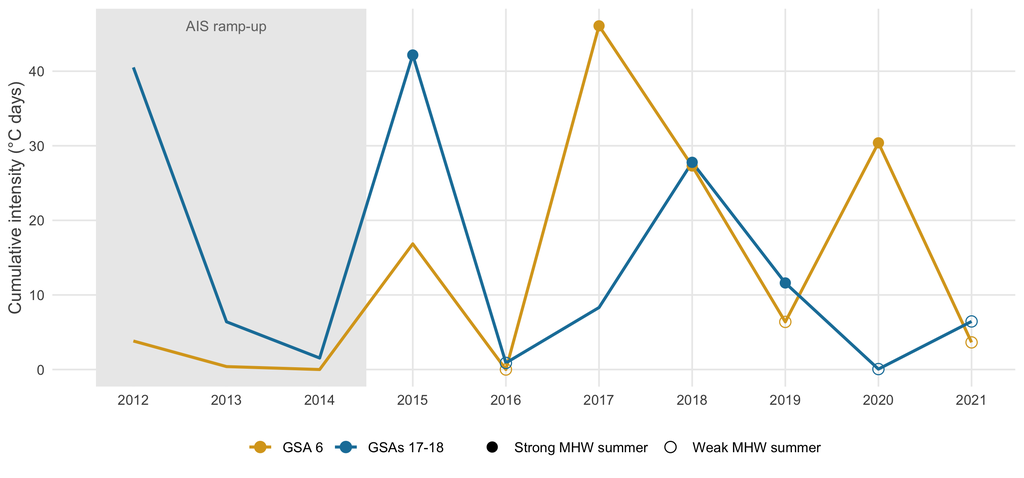

Figure 27: Mean summer cumulative heatwave intensity per year across each area’s prediction grid (°C days). Points mark the three strongest and three weakest summers from 2015 onward, after the AIS ramp-up, proposed as contrasting years for each area.

```r
mhw_pick <- mhw_year |>
  filter(YEAR >= 2015) |>
  group_by(region) |>
  mutate(rank = rank(-cum, ties.method = "first"),
         class = case_when(rank <= 3 ~ "Strong MHW summer", rank >= n() - 2 ~ "Weak MHW summer")) |>
  ungroup() |> filter(!is.na(class))

ggplot(mhw_year, aes(YEAR, cum, colour = region)) +
  annotate("rect", xmin = 2011.6, xmax = 2014.5, ymin = -Inf, ymax = Inf, fill = "grey92") +
  annotate("text", x = 2013, y = max(mhw_year$cum), label = "AIS ramp-up", colour = "grey45", size = 3.2) +
  geom_line(linewidth = 0.9) +
  geom_point(data = mhw_pick, aes(shape = class), size = 3) +
  scale_colour_manual(values = grp_cols, name = NULL) +
  scale_shape_manual(values = c(`Strong MHW summer` = 16, `Weak MHW summer` = 1), name = NULL) +
  scale_x_continuous(breaks = 2012:2021) +
  labs(x = NULL, y = "Cumulative intensity (°C days)") + theme_ocean()
```

```r
kable(mhw_pick |>
        mutate(lab = sprintf("%d (%.1f)", YEAR, cum)) |>
        arrange(region, class, YEAR) |>
        group_by(Area = region, class) |>
        summarise(years = paste(lab, collapse = ", "), .groups = "drop") |>
        pivot_wider(names_from = class, values_from = years))
```

Table 16: Proposed contrasting summers for each area, from 2015 onward. Area: GSA 6 or GSAs 17-18. Strong MHW summers, Weak MHW summers: the three years with the highest and lowest mean summer cumulative heatwave intensity across the area’s prediction grid (in brackets, °C days). The GSA 6 comparison in Section 3.2 uses 2017, 2018, 2020 against 2013, 2014, 2016.

| Area | Strong MHW summer | Weak MHW summer |
| --- | --- | --- |
| GSA 6 | 2017 (46.1), 2018 (27.3), 2020 (30.4) | 2016 (0.0), 2019 (6.4), 2021 (3.6) |
| GSAs 17-18 | 2015 (42.2), 2018 (27.8), 2019 (11.6) | 2016 (0.9), 2020 (0.1), 2021 (6.4) |

**Heatwave, biomass trend and trawling trend maps (scripts/6_MHW_trend_maps.R)**

```r
source("scripts/6_MHW_trend_maps.R")
trend_g <- bind_rows(trend_data("6") |> mutate(region = "GSA 6"),
                     trend_data("1718") |> mutate(region = "GSAs 17-18"))
```

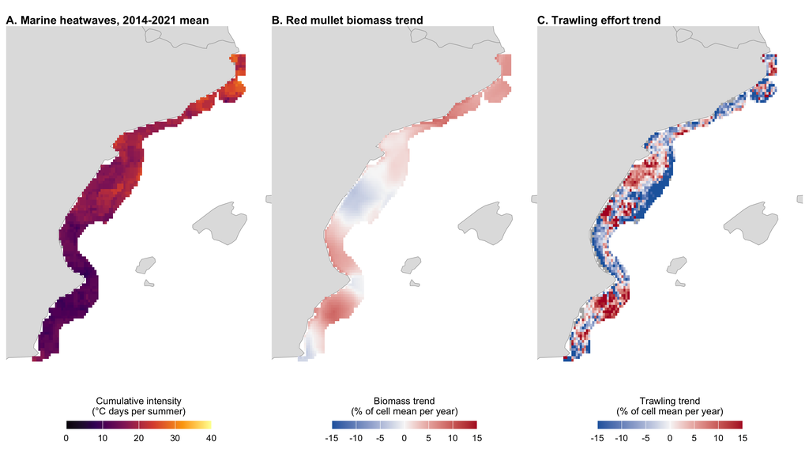

Figure 28: GSA 6. A: mean summer cumulative heatwave intensity, 2014-2021 (°C days per summer). B: linear trend in predicted red mullet biomass, 2014-2021, as a percentage of the cell’s mean biomass per year. C: linear trend in trawling hours, 2014-2021, as a percentage of the cell’s mean hours per year (grey: less than 1 hour per year on average). Trend colour scales are capped at ±15% per year.

```r
trend_maps("6", filter(trend_g, region == "GSA 6"))
```

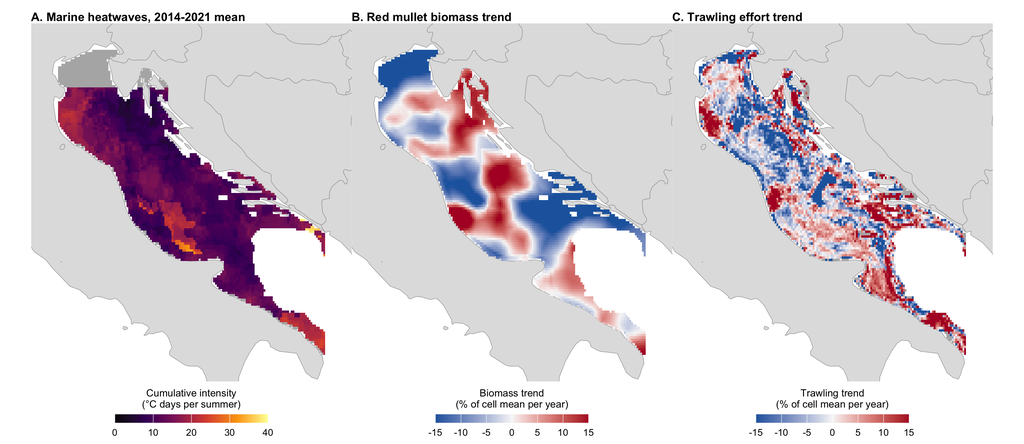

Figure 29: GSAs 17-18 (Adriatic). Panels as in the GSA 6 figure. Grey in A: no SST data (north of 45.0°N).

```r
trend_maps("1718", filter(trend_g, region == "GSAs 17-18"))
```

```r
kable(trend_g |>
        group_by(Area = region) |>
        summarise(`MHW intensity (°C days per summer)` = round(median(mhw_cum, na.rm = TRUE), 1),
                  `Biomass trend (%/yr)` = round(median(trend_bio), 1),
                  `Cells with biomass decline` = percent(mean(trend_bio < 0), 1),
                  `Trawling trend (%/yr)` = round(median(trend_eff, na.rm = TRUE), 1),
                  `Cells with trawling decline` = percent(mean(trend_eff < 0, na.rm = TRUE), 1),
                  `r (MHW, biomass trend)` = round(cor(mhw_cum, trend_bio, method = "spearman", use = "complete.obs"), 2),
                  `r (MHW, trawling trend)` = round(cor(mhw_cum, trend_eff, method = "spearman", use = "complete.obs"), 2)))
```

Table 17: Summary of the heatwave and trend layers by area. Area: GSA 6 or GSAs 17-18. MHW intensity (°C days per summer): median over cells of the 2014-2021 mean summer cumulative heatwave intensity. Biomass trend (%/yr), Trawling trend (%/yr): median over cells of the linear trend, as a percentage of the cell’s mean per year. Cells with biomass decline, Cells with trawling decline: share of cells with a negative trend. r (MHW, biomass trend), r (MHW, trawling trend): Spearman correlation across cells between heatwave intensity and each trend.

| Area | MHW intensity (°C days per summer) | Biomass trend (%/yr) | Cells with biomass decline | Trawling trend (%/yr) | Cells with trawling decline | r (MHW, biomass trend) | r (MHW, trawling trend) |
| --- | --- | --- | --- | --- | --- | --- | --- |
| GSA 6 | 16.5 | 1.6 | 26% | -1.7 | 57% | -0.05 | -0.24 |
| GSAs 17-18 | 11.5 | -0.9 | 53% | -0.2 | 50% | -0.17 | 0.11 |

Trends are shown relative to each cell’s mean, so that biomass (kg/km²) and effort (hours) are on the same scale and one threshold means the same for both. In GSA 6, predicted biomass rises slightly over most of the shelf, while trawling trends form a fine mosaic of increases and decreases. In the Adriatic, biomass trends follow the broad patches of the spatio-temporal field, and heatwave exposure is highest along the Italian coast and in the south.

> **Discussion points.** (1) The heatwave map in the group’s script grouped the data by year and cell, so the ten yearly maps were drawn on top of each other and only the last year was visible; here the panel shows the mean summer cumulative intensity over 2014-2021, the period of the trends. (2) The group classed trends as decreasing, stable or increasing with a threshold of ±0.1 in absolute units (kg/km² per year for biomass, hours per year for effort), which leaves only about 3% of cells “stable” in the Adriatic; relative trends, as here, or classes based on significance are more meaningful. Significance of the slopes is to be shared by the group and can then be used to grey out non-significant trends. (3) The biomass trends come from model predictions that include the spatio-temporal field, so in the Adriatic part of the pattern reflects year-to-year noise in that field. (4) The climatology uses 2010-2021, shorter than the 30-year baseline recommended by Hobday et al. (2016).